# Nonparametric Statistics - Epiphany term 2025

### 3.4.3 The curse of dimensionality

Modern data, such as gene expression (microarray) data, may have dimensions $d>10000$! Can we do KDE with aribtrary dimension $d$?

To answer this question, let us begin with a thought experiment. Let’s assume data $x_1, \ldots, x_n$ are sampled from a $d$-variate uniform distribution $\Omega= (U[0,1])^d$, with say $n=1000$. Now let’s take the bandwidth in each direction as

$$h_j\equiv h =1/4$$
and assume we are interested in estimating $f(x)$ at a point $x$ which sits sufficiently in the interior of the unit cube so that $x\pm h$ does not overlap with any boundary. The question that we ask is:

How many data points can be expected to be situated in the “minicube” centered at $x$, $\Omega_x= [x\pm 1/4]^d$?

We can easily work this out:

| $d$ | # points in $\Omega_x$ |
| --- | --- |
| $1$ | $(2\times 1/4 )\times 1000 = \frac{1}{2}\times 1000=500$ |
| $2$ | $(1/2^2) \times 1000=250$ |
| $3$ | $(1/2)^3\times 1000=125$ |
| $4$ | $(1/2)^4\times 1000=62.5$ |
| $\vdots$ | $\vdots$ |
| $10$ | $(1/2)^{10} \times 1000 < 1$ |

This illustrates the **curse of dimensionality**: Local neighborhoods in high dimensions tend to be sparse (almost empty). To counter this effect, one would need to hold $h^d n$ approximately constant. So if we assume $h^d n=c$ and $h<1$, this would mean
$$n=ch^{-d}= c \left(\frac{1}{h}\right)^d$$
where then $1/h>1$ and hence this means an exponential growth of $n$ is required. Or alternatively, one could try to increase the bandwidth accordingly, so that we would need
$$h \propto n^{-\frac{1}{d}}$$
This does actually look similar to our optimal bandwidth $h_{j, ROT} \propto n^{-1/(d+4)}$, which corresponds to a gentle increase of $h$ with increasing $d$, so perhaps there is a glimmer of hope? Let’s try!

**Example 3.14**

This example requires the availability of the following R packages

```r
require(plot3D)
require(rgl)
```

We consider again the Soils data, which features a range of further predictor variables. Let us successively increase the number of variables, and observe the behavior of the resulting KDE when using the ROT optimal bandwidths.

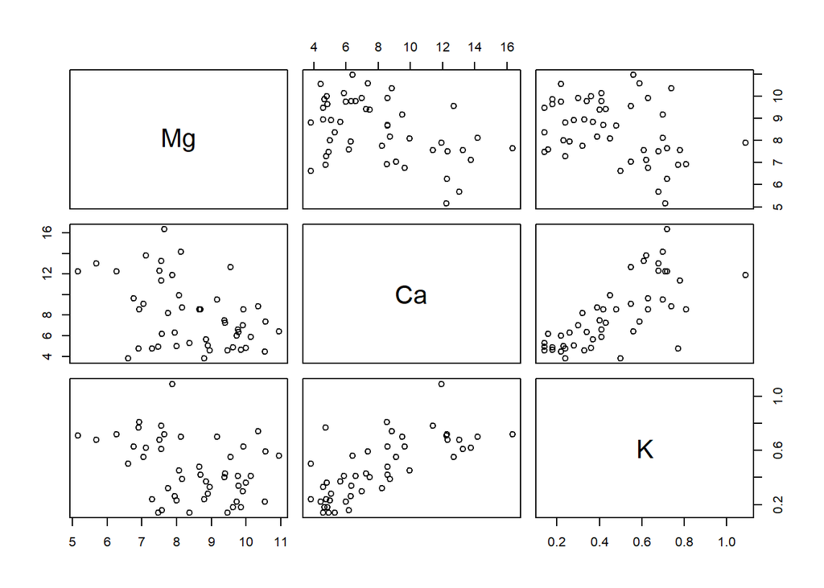

```r
soils3<- Soils[,c("Mg", "Ca", "K")]
plot(soils3)
```

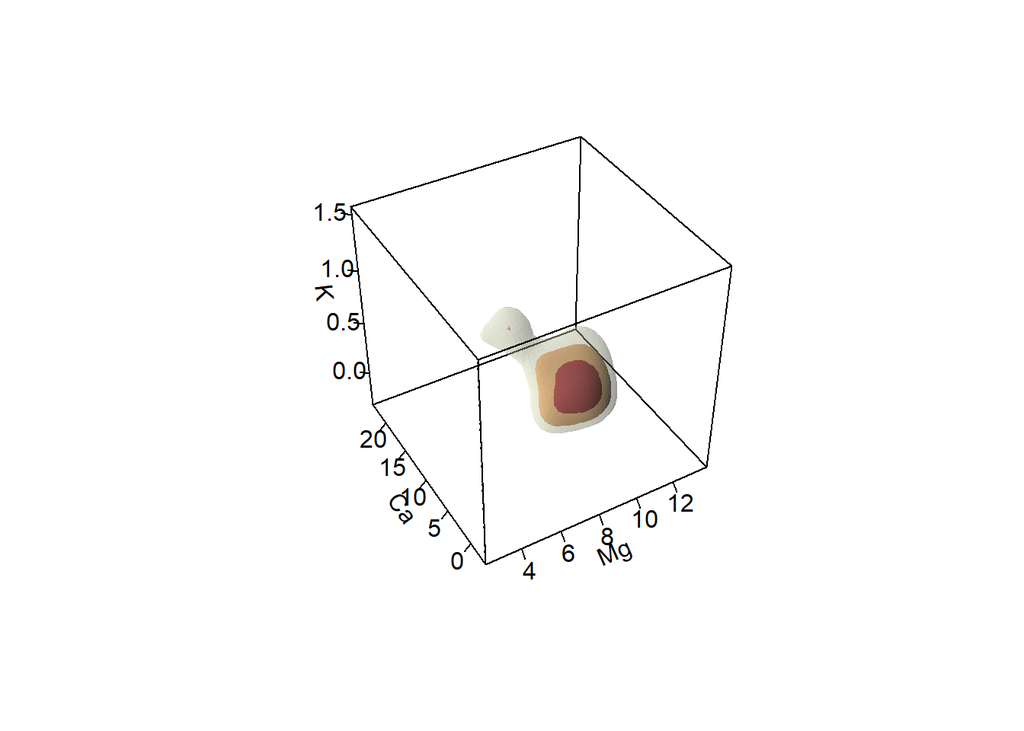

```r
h.soil3 <- hd.rot(soils3)
fit.soil3<-kde(soils3, H=diag(h.soil3^2))
plot(fit.soil3)
```

```r
plot(fit.soil3, display="rgl")
```

(Note the external window with the interactive RGL 3D-display which pops up when you run the chunk above!)

The scenario $d=3$ encounters some challenges in visualization, but by and large still works well.

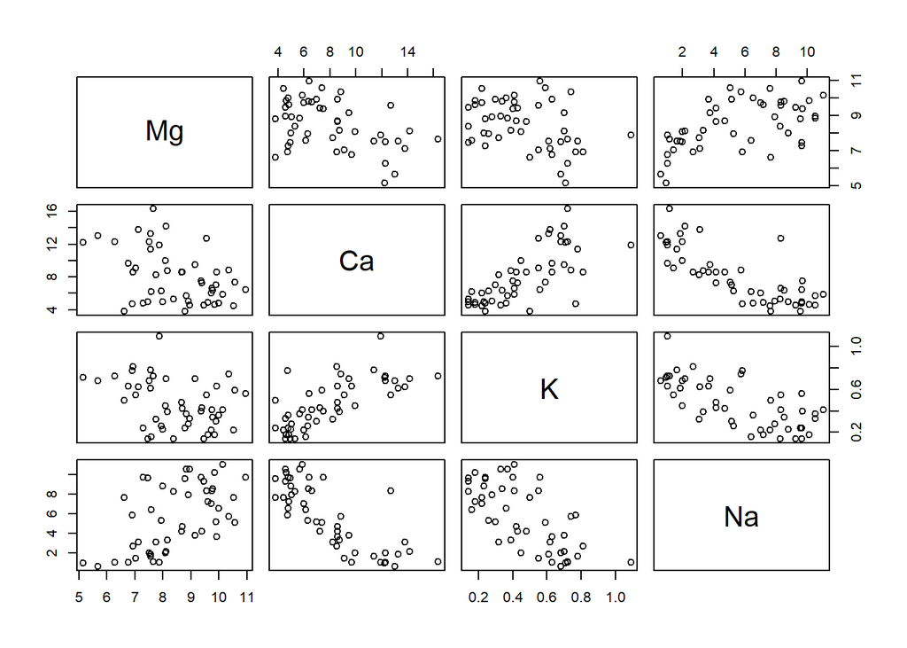

```r
soils4<- Soils[,c("Mg", "Ca", "K", "Na")]
plot(soils4)
```

```r
h.soil4 <- hd.rot(soils4)
fit.soil4<-kde(soils4, H=diag(h.soil4^2))
# plot(fit.soil4)     # commented out as it gives an error
names(fit.soil4)
```

```
##  [1] "x"           "eval.points" "estimate"    "H"           "gridtype"
##  [6] "gridded"     "binned"      "names"       "w"           "type"
## [11] "cont"
```

```r
# fit.soil4$estimate  # commented out as it needs lots of space
```

Can’t be visualized anymore. Estimates look quite “empty”.

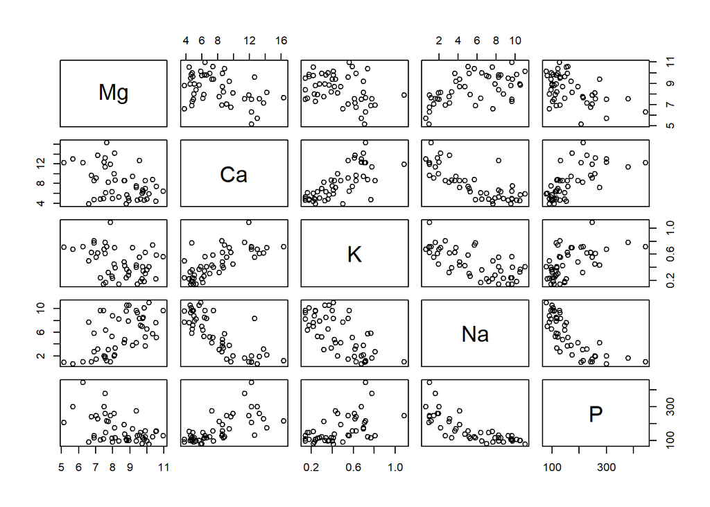

```r
 soils5<- Soils[,c("Mg", "Ca", "K", "Na", "P")]
 plot(soils5)
```

```r
 h.soil5 <- hd.rot(soils5)
 fit.soil5<-kde(soils5, H=diag(h.soil5^2))
```

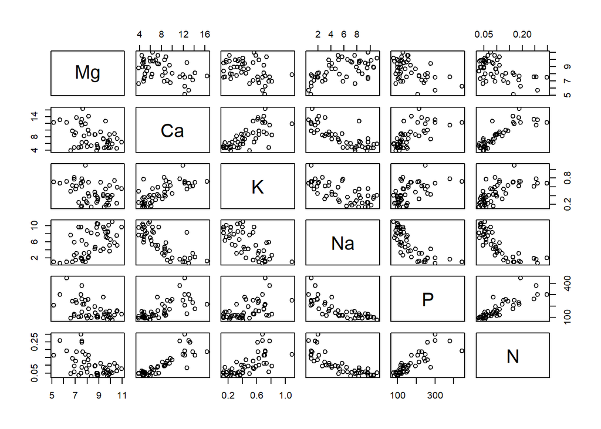

```r
 soils6<- Soils[,c("Mg", "Ca", "K", "Na", "P", "N")]
 plot(soils6)
```

```r
 h.soil6 <- hd.rot(soils6)
 # fit.soil6<-kde(soils6, H=diag(h.soil6^2))
 # this one took too long and in fact crashed my R session. Feel free to try :-)
```

Let’s compare the bandwidths used again.

```r
h.soil2
```

```
## [1] 0.717701 1.707931
```

```r
h.soil3
```

```
## [1] 0.7869971 1.8728366 0.1288146
```

```r
h.soil4
```

```
## [1] 0.8433256 2.0068830 0.1380344 2.0272460
```

```r
h.soil5
```

```
## [1]  0.8899095  2.1177399  0.1456592  2.1392278 52.7886334
```

These are gently increasing as expected. Let’s inspect a bit further.

Which grid sizes ($G$) have been used for each coordinate axis? (Note that, the number of evaluation points of the KDE is $G^d$!)

```r
length(fit.soil2$eval.points[[1]])
```

```
## [1] 151
```

```r
length(fit.soil3$eval.points[[1]])
```

```
## [1] 51
```

```r
length(fit.soil4$eval.points[[2]])
```

```
## [1] 21
```

```r
length(fit.soil5$eval.points[[3]])
```

```
## [1] 21
```

How many estimated density values does this result in?

```r
length(fit.soil2$estimate)
```

```
## [1] 22801
```

```r
length(fit.soil3$estimate)
```

```
## [1] 132651
```

```r
length(fit.soil4$estimate)
```

```
## [1] 194481
```

```r
length(fit.soil5$estimate)
```

```
## [1] 4084101
```

Observe, for instance, that $21^4=194481$.

How many (precisely) **zero** estimates are there?

```r
sum(fit.soil2$estimate==0)
```

```
## [1] 3269
```

```r
sum(fit.soil3$estimate==0)
```

```
## [1] 45473
```

```r
sum(fit.soil4$estimate==0)
```

```
## [1] 0
```

```r
sum(fit.soil5$estimate==0)
```

```
## [1] 0
```

How many de-facto **zero** estimates are there? (Let’s call a KDE value $\hat{f}_H(x)$ “de facto zero” if $\hat{f}_H(x) < 10^{-6} \times \max_z\hat{f}_H(z)$).

```r
sum(fit.soil2$estimate<1e-6*max(fit.soil2$estimate))
```

```
## [1] 3681
```

```r
sum(fit.soil3$estimate<1e-6*max(fit.soil3$estimate))
```

```
## [1] 57419
```

```r
sum(fit.soil4$estimate<1e-6*max(fit.soil4$estimate))
```

```
## [1] 124389
```

```r
sum(fit.soil5$estimate<1e-6*max(fit.soil5$estimate))
```

```
## [1] 3346029
```

Which proportion of estimates is precisely zero?

```r
sum(fit.soil2$estimate==0)/length(fit.soil2$estimate)
```

```
## [1] 0.1433709
```

```r
sum(fit.soil3$estimate==0)/length(fit.soil3$estimate)
```

```
## [1] 0.3428018
```

```r
sum(fit.soil4$estimate==0)/length(fit.soil4$estimate)
```

```
## [1] 0
```

```r
sum(fit.soil5$estimate==0)/length(fit.soil5$estimate)
```

```
## [1] 0
```

We see that, from $d=2$ to $d=3$, there is the expected behavior: The sparsity is gripping and therefore the proportion of estimates which are zero increases. However, what happens then is more worrying: From $d=3$ to $d=4$, the patches of “zero estimates” disappear, which is a “blurring” effect due to the larger bandwidths used.

Which proportion of estimates is de-facto zero?

```r
sum(fit.soil2$estimate<1e-6*max(fit.soil2$estimate))/length(fit.soil2$estimate)
```

```
## [1] 0.1614403
```

```r
sum(fit.soil3$estimate<1e-6*max(fit.soil3$estimate))/length(fit.soil3$estimate)
```

```
## [1] 0.4328576
```

```r
sum(fit.soil4$estimate<1e-6*max(fit.soil4$estimate))/length(fit.soil4$estimate)
```

```
## [1] 0.6395946
```

```r
sum(fit.soil5$estimate<1e-6*max(fit.soil5$estimate))/length(fit.soil5$estimate)
```

```
## [1] 0.8192816
```

The proportion of evaluation points attaining any non-negligible density values falls consistently with the dimension; the estimated density dilutes and gets “flattened out” across space as we proceed with higher dimensions.

# 4 Nonparametric regression

## 4.1 Introduction

### 4.1.1 Problem setup

Let $(X,Y)$ be continuous, univariate random variables with joint density $g(x,y)$ and marginal density of $X$ as $f(x)=\int g(x,y)\,dy$. The densities $f$ and $g$ are unknown.

We are given data $(x_1, y_1), \ldots, (x_n, y_n)$ which form an i.i.d. sampe from $(X,Y)$.

We are interested in a **model** for $Y$ given $X$ which does not require ``parametric” assumptions (such as in linear regression). Let us therefore assume (for now)
$$Y=m(X)+\tilde{\epsilon}$$

where $m:\mathbb{R}\longrightarrow \mathbb{R}$ is an unknown, twice differentiable (“smooth”) function, and $\tilde{\epsilon}$ is some random error with mean zero (which we give some more attention later in this introduction).

Note that the model above implies
$$E(Y|X=x)= m(x),$$
so the regression function $m(x)$ is just the conditional mean of $Y$ given that $X$ takes the value $x$.

**Task**: Estimate $m$.

### 4.1.2 Motivating kernel regression via KDE

To find an estimate of $m(x)$ at some fixed point $x$, note that

$$m(x)=E(Y|X=x)= \int y\, g(y|x)\,dy = \int y \frac{g(x,y)}{f(x)}\,dy$$
where have implicitly used the notation $g(y|x)$ for the conditional density of $Y$ given $X=x$. We do know how to estimate the densities $f(\cdot)$ and $g(\cdot, \cdot)$ via kernel density estimation, namely

$$\begin{align}
\hat{f}(x)&= \frac{1}{nh_1}\sum_{i=1}^nK\left(\frac{x_i-x}{h_1} \right);\\
\hat{g}(x,y)&= \frac{1}{nh_1h_2}\sum_{i=1}^nK\left(\frac{x-x_i}{h_1} \right)K\left(\frac{y-y_i}{h_2} \right).
\end{align}$$

Then we can estimate

$$\begin{align}
\hat{m}(x)&= \int y \frac{\hat{g}(x,y)}{\hat{f}(x)}\,dy\\
&= \int y \frac{\frac{1}{nh_1h_2}\sum_{i=1}^nK\left(\frac{x-x_i}{h_1} \right)K\left(\frac{y-y_i}{h_2} \right) }{\frac{1}{nh_1}\sum_{i=1}^nK\left(\frac{x-x_i}{h_1} \right)}\,dy\\
&=\frac{1}{h_2}\frac{1}{\sum_{i=1}^nK\left(\frac{x-x_i}{h_1} \right)}\times \sum_{i=1}^n
K\left(\frac{x-x_i}{h_1} \right)\int y K\left(\frac{y-y_i}{h_2} \right)\,dy
\end{align}$$
Now use the transformation $z=\frac{y-y_i}{h_2}$ which implies
$$y= h_2z+y_i$$
and hence also $dy=h_2dz$. Focusing on the intergral for the moment,

$$\begin{align}
\int y K\left(\frac{y-y_i}{h_2} \right)\,dy&= \int (h_2z+y_i) K(z) h_2\,dz\\
&= h_2^2\int zK(z)\,dz+h_2y_i\int K(z)\,dz\\
&= h_2y_i
\end{align}$$
Hence we have

$$\begin{align}
\hat{m}(x)&= \frac{1}{h_2}\frac{1}{\sum_{i=1}^nK\left(\frac{x-x_i}{h_1} \right)}\times \sum_{i=1}^n
K\left(\frac{x-x_i}{h_1} \right) h_2y_i\\
&= \frac{\sum_{i=1}^ny_iK\left(\frac{x-x_i}{h_1} \right)}{\sum_{i=1}^nK\left(\frac{x-x_i}{h_1} \right)}.
\end{align}$$

We see that the vertical bandwidth $h_2$ does not matter. Writing then $h\equiv h_1$, this becomes

$$\hat{m}_{NW}(x)= \frac{\sum_{i=1}^ny_iK\left(\frac{x-x_i}{h} \right)}{\sum_{i=1}^nK\left(\frac{x-x_i}{h} \right)}$$

which is known as the **Nadaraya-Watson** estimator of $m(x)$. Note that, for each point $x \in \mathbb{R}$, this is just a weighted mean of all (response) observations, with those responses $y_i$ which are (in terms of their associated predictor values $x_i$) further away from $x$ receiving smaller weight.

**Example 4.1**

We will consider two data sets for illustrative purposes:

- the `fossil` data, with ratios of certain strontium isotopes in $n=106$ fossil shells versus age (in millions of years);
- the `lidar` data, which are from a LIDAR (**Li**ght **D**etection **a**nd **R**anging) experiment with $n=221$.

Accessing these data requires installation of the R package **SemiPar**.

```r
# install.packages("SemiPar")
require(SemiPar)
```

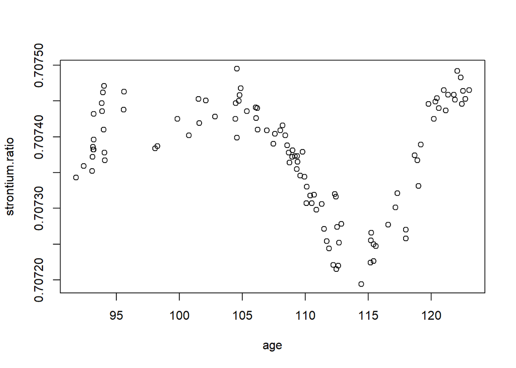

```r
data(fossil)
plot(fossil)
```

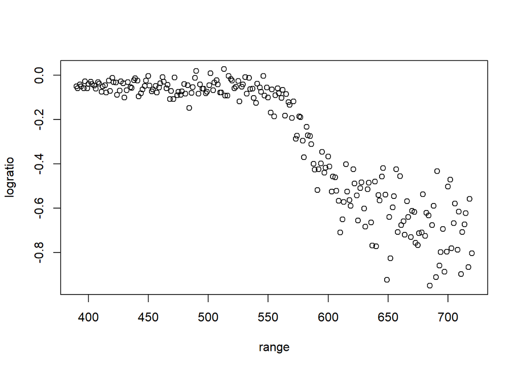

```r
data(lidar)
plot(lidar)
```

We firstly implement the Nadaraya-Watson estimator, for which we again make use of our `my.kernel` function implemented earlier:

```r
my.kernel.smoother<- function(xdat, ydat, xgrid=xdat, h){
  G<- length(xgrid)
  est<-rep(0,G)
  for (j in 1:G){
  est[j]<-
     sum(ydat*my.kernel((xgrid[j]-xdat)/h))/sum(my.kernel((xgrid[j]-xdat)/h))
  }
  return(as.data.frame(cbind(xgrid, est)))
}
```

We apply this function for a range of bandwidths on the `fossil` data….

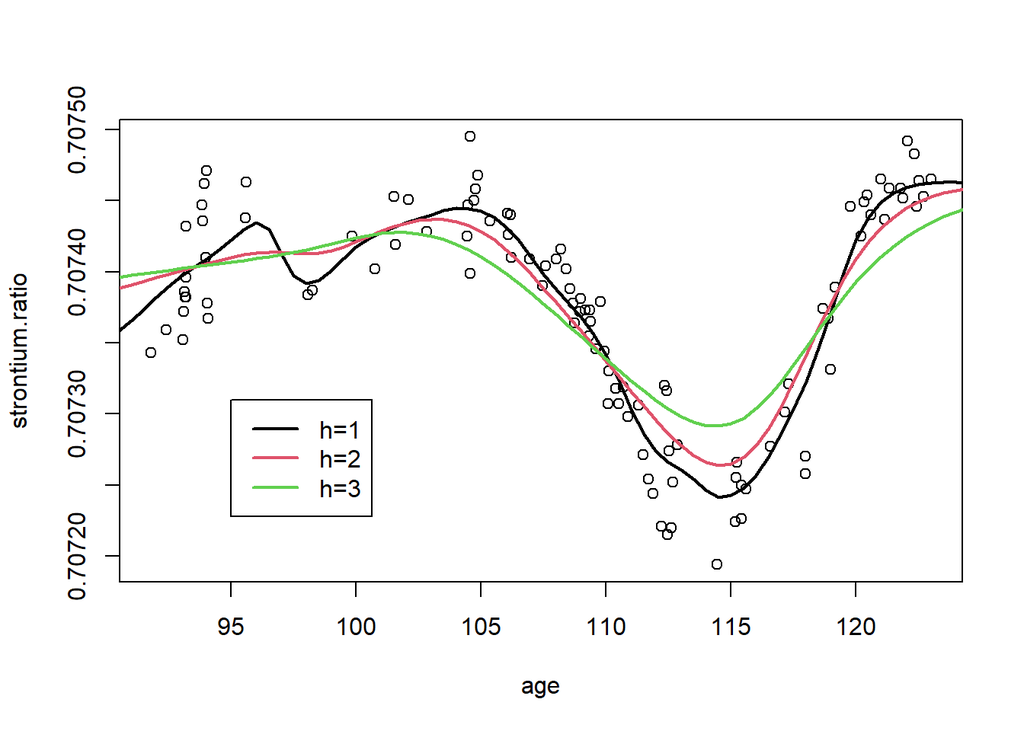

```r
age.grid<- seq(90, 130, by=0.5)
fit1<- my.kernel.smoother(fossil$age, fossil$strontium.ratio, age.grid, h=1)
fit2<- my.kernel.smoother(fossil$age, fossil$strontium.ratio, age.grid, h=2)
fit3<- my.kernel.smoother(fossil$age, fossil$strontium.ratio, age.grid, h=3)
plot(fossil)
lines(fit1, col=1, lwd=2)
lines(fit2, col=2, lwd=2)
lines(fit3, col=3, lwd=2)
legend(95,0.70731, c("h=1", "h=2", "h=3"), lwd=c(2,2,2), lty=c(1,1,1), col=c(1,2,3))
```

… and on the `lidar` data:

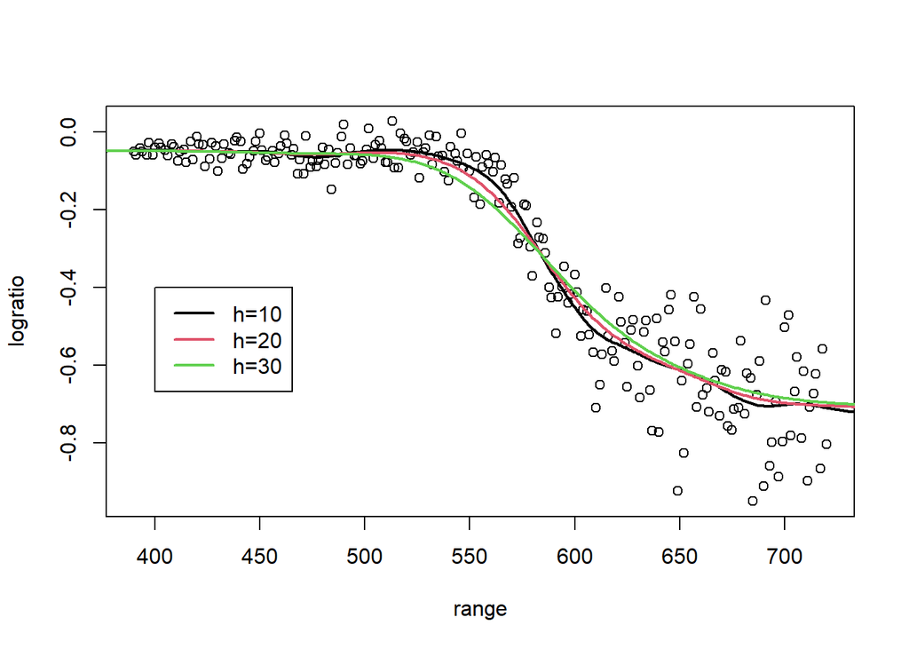

```r
range.grid<-350:750
fitl1<- my.kernel.smoother(lidar$range, lidar$logratio, range.grid, h=10)
fitl2<- my.kernel.smoother(lidar$range, lidar$logratio, range.grid, h=20)
fitl3<- my.kernel.smoother(lidar$range, lidar$logratio, range.grid, h=30)
plot(lidar)
lines(fitl1, col=1, lwd=2)
lines(fitl2, col=2, lwd=2)
lines(fitl3, col=3, lwd=2)
legend(400,-0.4, c("h=10", "h=20", "h=30"), lwd=c(2,2,2), lty=c(1,1,1), col=c(1,2,3))
```

The role of the bandwidth is hence similar as before; such as

- if $h$ is small, we get a “rough” estimate, with low bias, and high variance;
- if $h$ is large, we get a “smooth” estimate, with high bias, and low variance.

The sensitivity of the estimates to the bandwidth seems however not as strong as for the KDEs.

### 4.1.3 The nonparametric regression model

Looking back at the data examples from Example 4.1, we observe that for the `fossil` data, the variance of the data around the estimated curves appears to be approximately constant along the $x$ axis, whereas for the `lidar` data this is clearly not the case since the data show a “fanning out” effect for high `range` values. Such an unequal variance across the values of $x$ is known as heteroscedasticity, which our model should account for.

Therefore, the nonparametric regression model for i.i.d. data $(x_i, y_i)$, $i=1, \ldots, n,$ is generally formulated as

$$Y=m(X)+\sigma(X)\epsilon$$
where $E(\epsilon)=0$, $\mbox{Var}(\epsilon)=1$, $\epsilon$ independent of $X$, and hence

$$\begin{align}
E(Y|X=x)&= m(x)+\sigma(x)\times0 = m(x);\\
\mbox{Var}(Y|X=x)&= 0+\sigma^2(x)\times 1 = \sigma^2(x).
\end{align}$$
Models of this type are also called *location-scale models* since both location ($m(x)$) and scale ($\sigma^2(x)$) of $Y$ can be described by a single model.

If $\sigma^2(x)\equiv \sigma^2$ for all $x$ then we call the model *homoscedastic*, otherwise *heteroscadastic*.

The main interest clearly resides in the estimation of $m(x)$. The variance (scale) term is mainly relevant for correct inference on $m(x)$ (such as, variance of its estimate) rather than of intrinsic interest by itself.

## 4.2 Localized regression

### 4.2.1 Kernel regression as a weighted least squares problemn

Recall the Nadaraya-Watson (NW) estimator

$$\hat{m}_{NW}(x)= \frac{\sum_{i=1}^ny_iK\left(\frac{x-x_i}{h} \right)}{\sum_{i=1}^nK\left(\frac{x-x_i}{h} \right)}$$

Note this is just the solution of

$$\mbox{arg min}_{\beta_0}\sum_{i=1}^nK\left(\frac{x-x_i}{h}\right)(y_i-\beta_0)^2$$

**Proof**: Let us abbreviate $w_i(x)= K\left(\frac{x-x_i}{h}\right)$, and define

$$Q(\beta_0)= \sum_{i=1}^n w_ix(y_i-\beta_0)^2$$
which is the quantity to minimize. We do this by setting its derivative equal to zero,

$$\begin{align}
Q'(\beta_0)&= - 2 \sum_{i=1}^n w_i(x)(y_i-\beta_0)\stackrel{!}{=}0\\
\sum_{i=1}^n w_i(x)y_i&=\beta_0\sum_{i=1}^n w_i(x)\\
\beta_0&=\frac{\sum_{i=1}^n y_i w_i(x)}{\sum_{i=1}^n w_i(x)}
\end{align}$$
—

So, de facto $m(x)\approx \beta_0$ acts as a “localized model” for $m$ in a neighborhood of $x$, say $(x-h,x+h)$. We could improve this localized model by a Taylor expansion of first order

$$m(x) \approx \beta_0+\beta_1(z-x).$$

This then would require to estimate two parameters, $\beta_0$ and $\beta_1$, by

$$\mbox{arg min}_{\beta_0, \beta_1}\sum_{i=1}^nK\left(\frac{x-x_i}{h}\right)(y_i-\beta_0-\beta_1(x_i-x))^2$$

Note that, by Taylor’s theorem,

$$\begin{align}
\beta_0 &= m(x)\\
\beta_1 &= m'(x)
\end{align}$$
(Observe that the latter property would enable us to also do *derivative estimation*).

### 4.2.2 The local linear regression estimator

Consider

$$Q(\beta_0, \beta_1) = \sum_{i=1}^n w_i(x)(y_i-\beta_0-\beta_1(x_i-x))^2$$
where we are again using the abbreviation $w_i(x)\equiv K\left(\frac{x_i-x}{h} \right)$, and $\beta_0$ and $\beta_1$ are unknown parameters (Note that these actually depend on $x$, so we could write $\beta_0(x)$ and $\beta_1(x)$, but this depencene on $x$ is suppressed for notational ease. It is important to be aware of this, though.)

Now we find the values of $\beta_0$, $\beta_1$ at which $Q(\beta_0, \beta_1)$ attains its minimum by setting the gradient of $Q$ equal to zero,

$$\begin{align}
\frac{\partial Q}{\partial \beta_0}&= -2 \sum_{i=1}^nw_i(x)(y_i-\beta_0-\beta_1(x_i-x))\\
\frac{\partial Q}{\partial \beta_1}&= -2 \sum_{i=1}^nw_i(x)(y_i-\beta_0-\beta_1(x_i-x))(x_i-x)
\end{align}$$

This yields the two equations

$$\begin{align}
(1)\quad \sum_{i=1}^nw_i(x)y_i&= \beta_0 \sum_{i=1}^n w_i(x)+\beta_1 \sum_{i=1}^n w_i(x)(x_i-x)\\
(2)\quad \sum_{i=1}^n w_i(x)y_i(x_i-x)&=\beta_0\sum_{i=1}^nw_i(x)(x_i-x)+\beta_1\sum_{i=1}^nw_i(x)(x_i-x)^2
\end{align}$$

For better handling define the new notation $S_{n,j}=\sum_{i=1}^n w_i(x)(x_i-x)^j$, $j=0,1,2, \cdots$.

This means we can rewrite (1) and (2) as

$$\begin{align}
(1)\quad \sum_{i=1}^n w_i(x)y_i= \beta_0S_{n,0}+\beta_1S_{n,1}\\
(2)\quad \sum_{i=1}^n w_i(x)y_i(x_i-x)= \beta_0S_{n,1}+\beta_1S_{n,2}
\end{align}$$

Now we apply $(1)\times \frac{S_{n,2}}{S_{n,1}}-(2)$ to obtain

$$\begin{align}
\frac{S_{n,2}}{S_{n,1}}\sum w_i(x)y_i-\sum w_i(x)y_i(x_i-x)&=\beta_0\frac{S_{n,0}S_{n,2}}{S_{n1}} -\beta_0S_{n,1}\\
S_{n,2}\sum_{i=1}^nw_i(x)y_i-S_{n,1}\sum_{i=1}^n w_i(x)y_i(x_i-x)&=
\beta_0\left(S_{n,0}S_{n,2}-S_{n,1}^2\right)
\end{align}$$

Note that we can write the bracket in the denominator as

$$S_{n,0}S_{n,2}-S_{n,1}^2= \sum_{i=1}^n w_i(x)S_{n,2}-S_{n,1}\sum_{i=1}^nw_i(x)(x_i-x)= \sum_{i=1}^nw_i(x)(S_{n,2}-(x_i-x)S_{n,1})$$
Hence, the above becomes

$$\hat{\beta}_0= \frac{\sum_{i=1}^nw_i(x)(S_{n,2}-(x_i-x)S_{n,1})y_i}{\sum_{i=1}^nw_i(x)(S_{n,2}-(x_i-x)S_{n,1})}$$
(hats above $\beta_0$ and $\beta_1$ omitted in all but last equation for ease of notation). Let us now define the weights

$$v_i(x)= w_i(x)\left(S_{n,2}-(x_i-x)S_{n,1} \right).$$
Therefore, we obtain the *local linear regression estimator*

$$\hat{m}(x)=\hat{\beta}_0= \frac{\sum_{i=1}^n v_i(x)y_i}{\sum_{i=1}^n v_i(x)}$$
which is, just as the Nadaraya-Watson estimator, a locally weighted sum of the observations (albeit a more complicated one.)

**Example 4.2**

We would like to apply the local linear regression estimator on the `fossil` and `lidar` data. In order to implement this estimator, we firstly define auxiliary functions for $S_{n,j}$ and $v_i(x)$:

```r
Sn<- function(xdat, x, h, j){
snj<-  sum(my.kernel((xdat-x)/h)*(xdat-x)^j)
return(snj)
}
```

```r
vix<-function(xdat, x, h){
  my.kernel((xdat-x)/h)*( Sn(xdat,x,h,2)-(xdat-x)*Sn(xdat,x,h,1) )
}
# produces the entire vector v_1(x),...v_n(x)
```

Now we are in a position to implement the function for the actual local linear smoother:

```r
my.ll.smoother<- function(xdat, ydat, xgrid=xdat, h){
  G<- length(xgrid)
  est<-rep(0,G)
  for (j in 1:G){
  est[j]<-
     sum(ydat*vix(xdat,xgrid[j],h))/sum(vix(xdat,xgrid[j],h))
  }
  return(as.data.frame(cbind(xgrid, est)))
}
```

We apply this function now again on the `fossil` data.

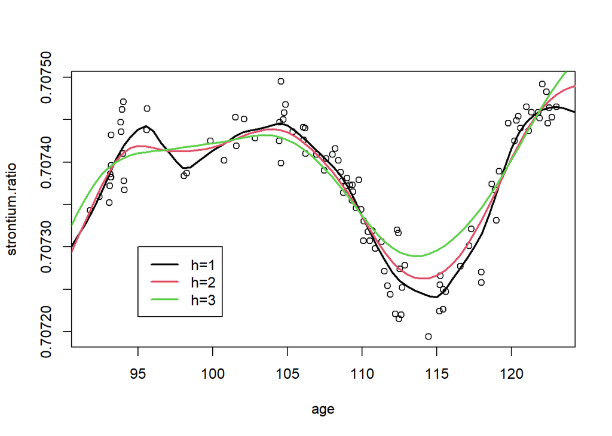

```r
age.grid<- seq(90, 130, by=0.5)
fit1<- my.ll.smoother(fossil$age, fossil$strontium.ratio, age.grid, h=1)
fit2<- my.ll.smoother(fossil$age, fossil$strontium.ratio, age.grid, h=2)
fit3<- my.ll.smoother(fossil$age, fossil$strontium.ratio, age.grid, h=3)
plot(fossil)
lines(fit1, col=1, lwd=2)
lines(fit2, col=2, lwd=2)
lines(fit3, col=3, lwd=2)
legend(95,0.70730, c("h=1", "h=2", "h=3"), lwd=c(2,2,2), lty=c(1,1,1), col=c(1,2,3))
```

The most obvious difference to the NW-estimator is the behavior in the left boundary: the smoother follows here the linear trend, rather than incorrectly flattening out at the boundary. The behavior in areas of strong curvature looks also improved. What we see here is a bias-reducing effect of the local linear estimate.

We now apply the local linear estimator on the `lidar` data.

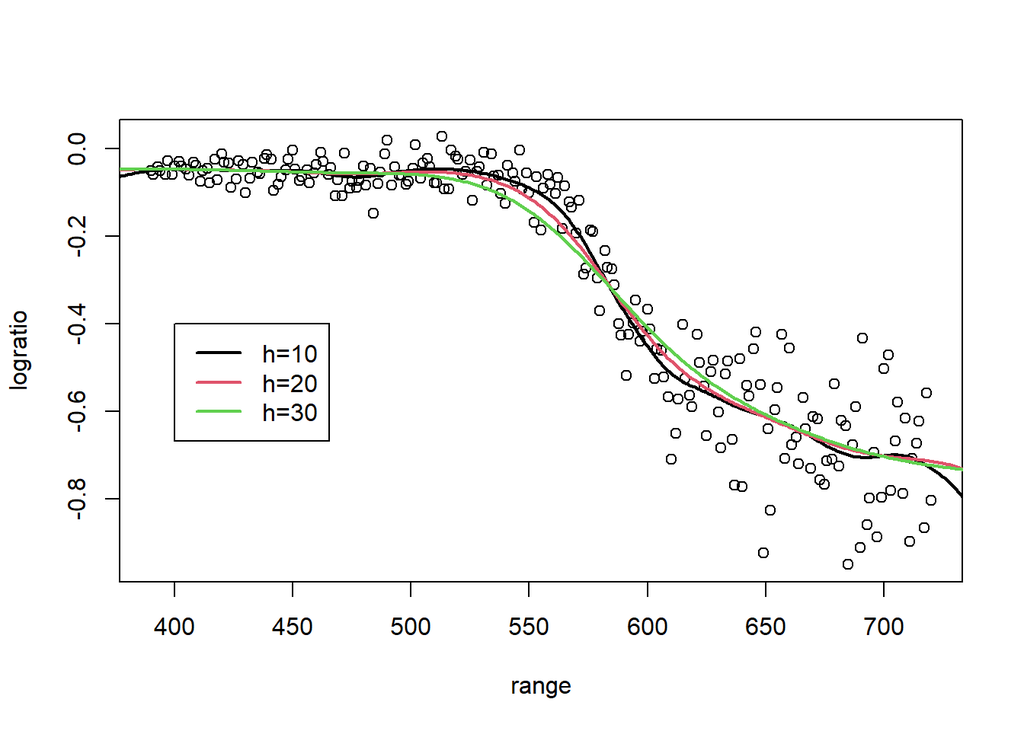

```r
range.grid<-350:750
fitl1<- my.ll.smoother(lidar$range, lidar$logratio, range.grid, h=10)
fitl2<- my.ll.smoother(lidar$range, lidar$logratio, range.grid, h=20)
fitl3<- my.ll.smoother(lidar$range, lidar$logratio, range.grid, h=30)
plot(lidar)
lines(fitl1, col=1, lwd=2)
lines(fitl2, col=2, lwd=2)
lines(fitl3, col=3, lwd=2)
legend(400,-0.4, c("h=10", "h=20", "h=30"), lwd=c(2,2,2), lty=c(1,1,1), col=c(1,2,3))
```

Here less difference to the NW estimator is noticeable, except perhaps at the right boundary where the local linear estimator for $h=10$ seems to overinterpret a potentially emerging linear trend.

### 4.2.3 Local polynomial regression

Consider Taylor’s theorem in ``Young’s form”: Assume $m^{(p)}$ is bounded at $x$, then

$$m(z)= \sum_{j=0}^p \frac{m^{(j)}(x)}{j!}(z-x)^j+o(|z-x|^p)$$
as $|z-x| \longrightarrow 0$.

This suggests we can locally approximate $m(x)$ by

$$m(z)\approx \sum_{j=0}^p\beta_j(z-x)^j,$$
where $\beta_j\equiv \frac{m^{(j)}(x)}{j!}$, and estimate $\beta_0,\ldots, \beta_p$ by minimizing

$$Q(\beta_0, \ldots, \beta_p)= \sum_{i=1}^nK\left(\frac{x_i-x}{h}\right)\left( y_i-\sum_{j=0}^p\beta_j(x_i-x)^j\right)^2$$
w.r.t. $\beta_0, \ldots, \beta_p$.

In matrix notation, define

$$\boldsymbol{X}= \left(\begin{array}{cccc}
1 & x_1-x & & (x_i-x)^p\\
\vdots&\vdots & \ddots & \vdots\\
1 & x_n-x & &(x_n-x)^p
\end{array} \right), \qquad
\boldsymbol{Y}= \left(\begin{array}{c}
y_1\\
\vdots\\
y_n
\end{array} \right),\qquad \boldsymbol{\beta}=\left(\begin{array}{c}
\beta_0\\
\vdots\\
\beta_p
\end{array} \right), \\
\boldsymbol{W}= \left(\begin{array}{ccc}
K\left(\frac{x_1-x}{h}\right) & &\\
&\ddots & \\
&& K\left(\frac{x_n-x}{h}\right)
\end{array} \right)= \left(\begin{array}{ccc}
w_1(x) & &\\
&\ddots & \\
&& w_n(x)
\end{array} \right).$$

Then

$$Q(\boldsymbol{\beta})= (\boldsymbol{Y}-\boldsymbol{X}\boldsymbol{\beta})^T\boldsymbol{W}(\boldsymbol{Y}-\boldsymbol{X}\boldsymbol{\beta})$$

We now minimize this w.r.t the vector $\boldsymbol{\beta}$:

$$\begin{align}
\frac{\partial}{\partial \boldsymbol{\beta}}Q(\boldsymbol{\beta})=-2\boldsymbol{X}^T\boldsymbol{W}(\boldsymbol{Y}-\boldsymbol{X}\boldsymbol{\beta})\stackrel{!}{=0}\\
\boldsymbol{X}^T\boldsymbol{W}\boldsymbol{Y}= \boldsymbol{X}^T\boldsymbol{W}\boldsymbol{X}\boldsymbol{\beta}\\
\end{align}$$
with solution
$$\hat{\boldsymbol{\beta}}= (\boldsymbol{X}^T\boldsymbol{W}\boldsymbol{X})^{-1}\boldsymbol{X}^T\boldsymbol{W}\boldsymbol{Y}$$

(which takes the familar shape of the multiple linear regression estimator, but with the additional weight matrix $\boldsymbol{W}$).

Now define vectors $e_j^T= (0,\ldots,0,1,0,\ldots,0) \in \mathbb{R}^{p+1}$ with 1 at $j$-th position; in particular $e_1^T=(1,0,\ldots,0)$. Then we see easily

$$\begin{align}
\hat{m}(x)&=\hat{\beta}_0=e_1^T\boldsymbol{\beta}\\
&= e_1^T(\boldsymbol{X}^T\boldsymbol{W}\boldsymbol{X})^{-1}\boldsymbol{X}^T\boldsymbol{W}\boldsymbol{Y}\\
&=
\left\{
\begin{array}{ll}
\hat{m}_{NW}(x) &\mbox{ if } p=0 \\
\hat{m}_{LL}(x) &\mbox{ if } p=1
\end{array}
\right.
\end{align}$$
(The last equality is not obvious, but can be shown with a bit of algebra when using the respective forms of $\boldsymbol{X}$ for $p=0$ and $p=1$, respectively.)

We also see that a *derivative estimate* can be obtained as

$$\hat{m}'(x)= \hat{\beta}_1=e_2^T\hat{\boldsymbol{\beta}}= e_2^T(\boldsymbol{X}^T\boldsymbol{W}\boldsymbol{X})^{-1}\boldsymbol{X}^T\boldsymbol{W}\boldsymbol{Y}$$

### 4.2.4 Bias and variance

From the matrix representation of $\hat{\boldsymbol{\beta}}$, we find

$$\mbox{Bias}(\hat{\boldsymbol{\beta}})= E(\hat{\boldsymbol{\beta}})- \boldsymbol{\beta}= (\boldsymbol{X}^T\boldsymbol{W}\boldsymbol{X})^{-1}\boldsymbol{X}^T\boldsymbol{W}E(\boldsymbol{Y})- \boldsymbol{\beta}.$$
It is worth investing a few thoughts on what $E(\boldsymbol{Y})$ actually is. This *could* have been interpreted as the expectation of the marginal density of $\boldsymbol{Y}$, that is after integration over the predictors. However this is not what is meant and what is usually done. Recall that, for (parametric) multiple regression, all inferences are always conditional on the observed predictor values. Precisely the same is done here. That is, $E(Y)$ is in fact the expectation of the responses conditional on $x_1, \ldots, x_n$ (even though usually we will not make this explicit notationally), that is

$$\begin{align}
E(\boldsymbol{Y})&\equiv E(\boldsymbol{Y}| x_1, \ldots, x_n)=
E\left(\begin{array}{c|c}
y_1 & \\ \vdots &x_1, \ldots, x_n \\ y_n & \end{array}\right)\\
&= \left(\begin{array}{c}
E(y_1 |x_1, \ldots, x_n) \\ \vdots \\ E(y_n |x_1, \ldots, x_n) \end{array}\right)
= \left(\begin{array}{c}m(x_1) \\ \vdots \\ m(x_n) \end{array}\right) \equiv \boldsymbol{M}.
\end{align}$$
So

$$\begin{align}
\mbox{Bias}(\hat{\boldsymbol{\beta}})&= (\boldsymbol{X}^T\boldsymbol{W}\boldsymbol{X})^{-1}\boldsymbol{X}^T\boldsymbol{W}\boldsymbol{M}- \boldsymbol{\beta}\\
&= (\boldsymbol{X}^T\boldsymbol{W}\boldsymbol{X})^{-1}\boldsymbol{X}^T\boldsymbol{W}(\boldsymbol{X}\boldsymbol{\beta}+\boldsymbol{M} -\boldsymbol{X}\boldsymbol{\beta} )- \boldsymbol{\beta}\\
&= \boldsymbol{\beta}+ (\boldsymbol{X}^T\boldsymbol{W}\boldsymbol{X})^{-1}\boldsymbol{X}^T\boldsymbol{W}(\boldsymbol{M} -\boldsymbol{X}\boldsymbol{\beta} )- \boldsymbol{\beta}\\
&=(\boldsymbol{X}^T\boldsymbol{W}\boldsymbol{X})^{-1}\boldsymbol{X}^T\boldsymbol{W}(\boldsymbol{M} -\boldsymbol{X}\boldsymbol{\beta} )
\end{align}$$
Note that in this expression, both $\boldsymbol{M}$ and $\boldsymbol{\beta}$ are unknown. Before we go further with this, let’s have a look at the variance.

$$\begin{align}
\mbox{Var}(\hat{\boldsymbol{\beta}})&= \mbox{Var}\left((\boldsymbol{X}^T\boldsymbol{W}\boldsymbol{X})^{-1}\boldsymbol{X}^T\boldsymbol{W}\boldsymbol{Y} \right)\\
&= (\boldsymbol{X}^T\boldsymbol{W}\boldsymbol{X})^{-1}\boldsymbol{X}^T\boldsymbol{W}\mbox{Var}(\boldsymbol{Y})
\boldsymbol{W}\boldsymbol{X}(\boldsymbol{X}^T\boldsymbol{W}\boldsymbol{X})^{-1}\end{align}$$
where we again examine $\mbox{Var}(\boldsymbol{Y})$ as follows

$$\begin{align}
\mbox{Var}(\boldsymbol{Y})&= \mbox{Var}\left(\begin{array}{c|c}
y_1 & \\ \vdots &x_1, \ldots, x_n \\ y_n & \end{array}\right)\\
&=\left[\mbox{Cov}(y_i, y_j|x_i, x_j)\right]_{1 \le i,j \le n}\\
&=\left(\begin{array}{ccc}
\mbox{Var}(y_1|X=x_1) &&\\
& \ddots &\\
&& \mbox{Var}(y_n|X=x_n)
\end{array}
\right)\\
&= \left(
\begin{array}{ccc}
\sigma^2(x_1) &&\\
&\ddots & \\
&& \sigma^2(x_n)\\
\end{array}\right)
\equiv \boldsymbol{V}
\end{align}$$

so that

$$\mbox{Var}(\hat{\boldsymbol{\beta}})= (\boldsymbol{X}^T\boldsymbol{W}\boldsymbol{X})^{-1}\boldsymbol{X}^T\boldsymbol{W}\boldsymbol{V}
\boldsymbol{W}\boldsymbol{X}(\boldsymbol{X}^T\boldsymbol{W}\boldsymbol{X})^{-1}.$$
Note that in this expression, only $\boldsymbol{V}$ is unknown.

In particular, we get for the bias and variance of the estimate of the regression mean function,

$$\begin{align}
\mbox{Bias}(\hat{m}(x))&= \mbox{Bias}(e_1^T\hat{\boldsymbol{\beta}})= e_1^T \mbox{Bias}(\hat{\boldsymbol{\beta}})\\
&= e_1^T(\boldsymbol{X}^T\boldsymbol{W}\boldsymbol{X})^{-1}\boldsymbol{X}^T\boldsymbol{W}(\boldsymbol{M} -\boldsymbol{X}\boldsymbol{\beta} );\\
\mbox{Var}(\hat{m}(x))&= \mbox{Var}(e_1^T\hat{\boldsymbol{\beta}})= e_1^T\mbox{Var}(\hat{\boldsymbol{\beta}})e_1\\
&= e_1^T(\boldsymbol{X}^T\boldsymbol{W}\boldsymbol{X})^{-1}\boldsymbol{X}^T\boldsymbol{W}\boldsymbol{V}
\boldsymbol{W}\boldsymbol{X}(\boldsymbol{X}^T\boldsymbol{W}\boldsymbol{X})^{-1}e_1
\end{align}.$$

### 4.2.5 Asymptotic approximations

We focus here on the local linear case, that is $p=1$, and will only give the proof for the asymptotic bias explicitly. Full results and derivations can be found in Wand & Jones, 1995, and Fan & Gijbels, 1996.

So, in the case $p=1$, recall that

$$\begin{align}
\boldsymbol{\beta}= \left(\begin{array}{c}
m(x)\\
m'(x)
\end{array}\right), \qquad \boldsymbol{X}=
\left(
\begin{array}{CC}
1 & x_1-x\\
\vdots & \vdots\\
1 & x_n-x
\end{array}
\right), \qquad \boldsymbol{M}=
\left(
\begin{array}{c}
m(x_1)\\
\vdots\\
m(x_n)
\end{array}
\right)
\end{align}$$
So,

$$\begin{align}
\boldsymbol{M}- \boldsymbol{X}{\boldsymbol{\beta}}&= \left(
\begin{array}{c}
m(x_1)\\
\vdots\\
m(x_n)
\end{array}
\right)- \left(
\begin{array}{CC}
1 & x_1-x\\
\vdots & \vdots\\
1 & x_n-x
\end{array}
\right)\left(
\begin{array}{c}
m(x_1)\\
\vdots\\
m(x_n)
\end{array}
\right)
\\
&= \left(
\begin{array}{c}
m(x_1)-m(x)-m'(x)(x_1-x))\\
\vdots\\
m(x_n)-m(x)-m'(x)(x_n-x)
\end{array}
\right)
\end{align}$$
We know, by Taylor expansion,

$$m(x_i)= m(x)+(x_i-x)m'(x)+\frac{1}{2}(x_i-x)^2m''(x)+o(|x_i-x|^2)$$

Hence

$$\mbox{Bias}(\hat{m}(x))= \frac{1}{2}e_1^Tm''(x)(\boldsymbol{X}^T\boldsymbol{W}\boldsymbol{X})^{-1}\boldsymbol{X}^T\boldsymbol{W}\left(\begin{array}{c} (x_1-x)^2\\
\vdots\\
(x_n-x)^2
\end{array}\right)$$
plus a remainder term which is that $o(\cdot)$ of the given expression. Next, we work out

$$\begin{align}
\boldsymbol{X}^T\boldsymbol{W}\left(\begin{array}{c} (x_1-x)^2\\
\vdots\\
(x_n-x)^2
\end{array}\right)&= \left(\begin{array}{ccc}
1 & \cdots & 1\\
x_1-x & \cdots & x_n-x\\
\end{array}\right)
\left(\begin{array}{ccc}
w_1(x) &&\\
& \ddots & \\
&& w_n(x)
\end{array}\right)\left(\begin{array}{c} (x_1-x)^2\\
\vdots\\
(x_n-x)^2
\end{array}\right)\\
&= \left(\begin{array}{ccc}
1 & \cdots & 1\\
x_1-x & \cdots & x_n-x\\
\end{array}\right)
\left(
\begin{array}{c}
w_1(x)(x_1-x)^2\\
\vdots\\
w_n(x)(x_n-x)^2
\end{array}
\right)\\
&=
\left(
\begin{array}{c}
\sum_{i=1}^n w_i(x)(x_i-x)^2\\
\sum_{i=1}^n w_i(x)(x_i-x)^3
\end{array}
\right)=
\left(
\begin{array}{c}
S_{n,2}\\
S_{n,3}
\end{array}
\right)
\end{align}$$
Similarly,

$$\boldsymbol{X}^T\boldsymbol{W}\boldsymbol{X}=
\left(
\begin{array}{cc}
S_{n,0} & S_{n,1}\\
S_{n,1} & S_{n,2}
\end{array}
\right).$$
It remains to approximate
$$S_{n,j}= \sum_{i=1}^nw_i(x)(x_i-x)^j= \sum_{i=1}^n K\left(\frac{x_i-x}{h}\right)(x_i-x)^j$$
by

$$\begin{align}
E(S_{n,j})&= n \int K\left(\frac{z-x}{h}\right)(z-x)^jf(z)\,dz\\
&= n \int K(u) (hu)^j f(x+hu)h\,du\\
&= nh^{j+1}\int u^j K(u)(f(x)+hu f'(x) +O(h^2))\,du\\
&= nh^{j+1}\left(f(x)\int u^jK(u)\,du +hf'(x)\int u^{j+1}K(u)\,du +O(h^2) \right)\\
&= nh^{j+1}\left(f(x)\mu_j +hf'(x)\mu_{j+1}+O(h^2\right)
\end{align}$$
where we have used the transformation $(z-x)/h=u$, hence $dz=h\,du$, and also our earlier notation
$$\mu_j= \int u^jK(u)\,du.$$

[Technical note: Why are we allowed to approximate $S_{n,j}$ by $ES_{nj}$? We do not want to get hung up on this point as it is technicality which in itself not very interesting, but basically one can show from Chebychev’s inequality that for any sequence of real random variables $X_n$ it holds that $X_n=EX_n+O_P\left(\sqrt{\mbox{Var}(X_n)}\right)$, where $O_P$ means “bounded in probability for large $n$”. So, if the variance term vanishes for large $n$, which one can show for the $S_{n,j}$ with some effort to be the case, then $ES_{n,j}$ is approximately equal to $S_{n,j}$, with probability approaching 1 for large $n$. In the literature, this property is also expressed as $S_{n,j}=ES_{n,j}+o_p(1)$, where $o_P(1)$ is a sequence which converges to 0, with a probability converging to 1, for large $n$. So, technically all appearances of $o(1)$ downstream in this proof are then to be understood as $o_P(1)$ too, even though we will refrain from making this notationally explicit in this exposition. See also Wand & Jones, Appendix A].

It is now important to spot that, for symmetric kernels, the odd moments $\mu_1$, $\mu_3$, are equal to zero. With that, we find

$$\begin{align}
\boldsymbol{X}^T\boldsymbol{W}\left(\begin{array}{c} (x_1-x)^2\\
\vdots\\
(x_n-x)^2
\end{array}\right)&=
\left(\begin{array}{c}
nh^3(f(x)\mu_2+o(1))\\
nh^5(f(x)\mu_4+o(1))
\end{array}\right)\\
\boldsymbol{X}^T\boldsymbol{W}\boldsymbol{X}&=
\left(\begin{array}{cc}
nh(f(x)+o(1)) & nh^3(f'(x)\mu_2+o(1))\\
nh^3(f'(x)\mu_2+(o(1)) & nh^3(f(x)\mu_2+o(1))
\end{array}\right).
\end{align}$$
Now, note that the expression for the Bias term above contains the product
$$e_1^T(\boldsymbol{X}^T\boldsymbol{W}\boldsymbol{X})^{-1}.$$

where $e_1^T=(1,0)$. This means, we actually only need to work out the first row of $(\boldsymbol{X}^T\boldsymbol{W}\boldsymbol{X})^{-1}$. Hence we have

$$\begin{align}
(\boldsymbol{X}^T\boldsymbol{W}\boldsymbol{X})^{-1}&= \frac{1}{n^2h^4f^2(x)\mu_2-n^2h^6f'(x)^2\mu_2^2}
\left(
\begin{array}{cc}
nh^3(f(x)\mu_2+o(1)) & -nh^3(f'(x)\mu_2+o(1)\\
\ldots & \ldots
\end{array}
\right)
\end{align}$$
so that we can finally compute

$$\begin{align}
\mbox{Bias}(\hat{m}_{LL}(x))&= \frac{1}{2}m''(x)\frac{h^2}{nh^3f^2(x)\mu_2-nh^5f'(x)\mu_2}
\underbrace{\left(f(x)\mu_2+o(1), -f'(x)\mu_2+o(1) \right)\left(\begin{array}{c}
nh^3(f(x)\mu_2+o(1))\\
nh^5(f'(x)\mu_4+o(1))
\end{array}\right)}_{nh^3(f^2(x)\mu_2^2+o(1))}\\
&= \frac{1}{2}h^2m''(x)\mu_2+o(h^2).
\end{align}$$
For the variance, a similar calculation can be carried out, which requires, beside the already available approximation of $(\boldsymbol{X}^T\boldsymbol{W}\boldsymbol{X})^{-1}$, also an approximation of $\boldsymbol{X}^T\boldsymbol{W}\boldsymbol{V}\boldsymbol{W}\boldsymbol{X}$. This is not more difficult but we omit this here, see also Wand & Jones, page 122, or Fan & Gijbels, page 101. The resulting expression takes the shape

$$\mbox{Var}(\hat{m}_{LL}(x))= \frac{1}{nh} \frac{\nu_0}{f(x)}+o\left(\frac{1}{nh}\right),$$
recalling our earlier notation $\nu_j= \int u^jK^2(u)\,du$.

Concluding, we see that, for the local linear estimator, when the bandwidth increases, the bias increases and the variance decreases, as expected. Furthermore, the bias is larger in areas of high curvature of the regression function, and the variance is larger for regions of high error variance or *low* data density. It may also be noted that the local linear estimator is approximately unbiased if the function $m$ is in fact linear.

Corresponding formulae for the local constant (Nadaraya-Watson) can be derived under the setting $p=0$ (see also Fan & Gijbels (1996), page 17, 62):

$$\begin{align}
\mbox{Bias}(\hat{m}_{NW}(x))&= \frac{1}{2}h^2\mu_2\left(m''(x)+2m'(x)\frac{f'(x)}{f(x)}\right)+o(h^2)\\
\mbox{Var}(\hat{m}_{NW}(x))&= \frac{1}{nh} \frac{\nu_0}{f(x)}+o\left(\frac{1}{nh}\right)
\end{align}$$
The key takeaway from these expressions is that the bias contains an additional term (as compared to the local linear estimator), which depends on the slope of the regression function and the design density, whereas the variance term is exactly the same as for the local linear estimator. This means, in turn, that the local linear estimator *reduces the bias without an increase in variance*. Therefore, in practice, it is the local linear estimator that should be used with preference over the NW-estimator.

This is a general principle which we would find reflected in equations for higher-order local polynomials (not displayed here): “Odd” polynomials are generally to be preferred over “even” ones; and for the estimation of $j$th derivatives, odd values of $p-j$ are preferred over even values of $p-j$. See also Wand & Jones page 137, Fan & Gijbels page 62.

### 4.2.6 Bandwidth selection

From the bias and variance approximations of $\hat{m}_{LL}(x)$, i.e. in the case $p=1$, we have

$$\begin{align}
M(h)\equiv MISE(\hat{m}_{LL})&= \int \mbox{Bias}^2(\hat{m}_{LL}(x))\,dx+ \int \mbox{Var}(\hat{m}_{LL}(x))\,dx\\
&= \frac{1}{4}h^4 \mu_2^2\int m''(x)^2\,dx + \frac{1}{nh}\nu_0 \int \sigma^2(x)/f(x) \,dx.
\end{align}$$

From this we can find an optimal bandwidth by differentiating as usual,

$$\frac{d M(h)}{dh}= h^3\mu_2^2\int m''(x)^2\,dx-\frac{1}{nh^2}\nu_0\int \sigma^2(x)/f(x)\,dx\stackrel{!}{=}0$$
which we solve as follows

$$\begin{align}
h^3\mu_2^2\int m^{''}(x)^2\,dx &= \frac{1}{nh^2}\nu_0 \int \frac{\sigma^2(x)}{f(x)}\,dx\\
h^5&= \frac{\nu_0}{\mu_2^2}\frac{\int \sigma^2(x)/f(x)\,dx}{\int m^{''}(x)^2\,dx}n^{-1}\\
h_{opt}&= \left[\frac{\nu_0}{\mu_2^2}\frac{\int \sigma^2(x)/f(x)\,dx}{\int m^{''}(x)^2\,dx} \right]^{1/5} n^{-1/5}
\end{align}$$

We firstly note this is again of order $n^{-1/5}$ as for KDE.

An obvious issue with this expression is that it involves the unknown quantities $\sigma^2(x)$, $f(x)$ and $m''(x)$. The idea is use pilot-estimators of $m$ to inform these quantities which are then plugged into $h_{opt}$. This approach is generally known as “plug-in” techniques.

A particularly simple plug-in technique is the “Rule-of-thumb” bandwidth selector by Fan & Gijbels (1996), for the local linear case ($p=1$). Under this approach,

- estimate $\hat{m}(x)$ globally by a polynomial of degree 4, i.e.
  $$\check{m}(x)= \hat{\alpha}_0+\check{\alpha}_1x+\check{\alpha_2}x^2+\check{\alpha}_3x^3+\check{\alpha}_4x^4$$
- estimate a constant error standard deviation $\sigma$ from the residuals of this fitted model,
  $$\check{\sigma}^2=\frac{1}{n-5}\sum_{i=1}^n(y_i-\check{m}(x_i))^2$$
- compute
  $$\check{m}''(x)= 2 \check{\alpha}_2+6 \check{\alpha}_3x+12\check{\alpha}_4x^2$$

Then the “rule of thumb” bandwidth is

$$h_{ROT}= \left[\frac{\nu_0}{\mu_2^2} \frac{\check{\sigma}^2}{\sum_{i=1}^n\check{m}''(x)^2} \right]^{1/5}n^{-1/5}$$
This would be easly implementable with our abilities. However, we will not do this now, as an implementation is available with R function `thumbBW` of R package `locpol`.

More advanced plug-in techniques use full semi-or nonparametric estimates of $m''(x)$, $f(x)$ and $\sigma^2(x)$. An example for an implementation of such a technique is R function `dpill` in R package `KernSmooth`.

**Example 4.3**

We initially use R function `locpol` to reproduce our earlier, manually implemented, estimates. Note that the default setting of `locpol` is a polynomial degree `deg=1`, that is local linear, and that the default kernel is Epanechnikov, which we change now to Gaussian. Let’s begin with the `fossil` data.

```r
require(locpol)
fit2a<- locpol(strontium.ratio~age, bw=2, deg=1,  kernel=gaussK, xeval=age.grid,  data=fossil)
```

This gives a few standard outputs which we do understand, albeit without having seen all specific methodological details for this estimator:

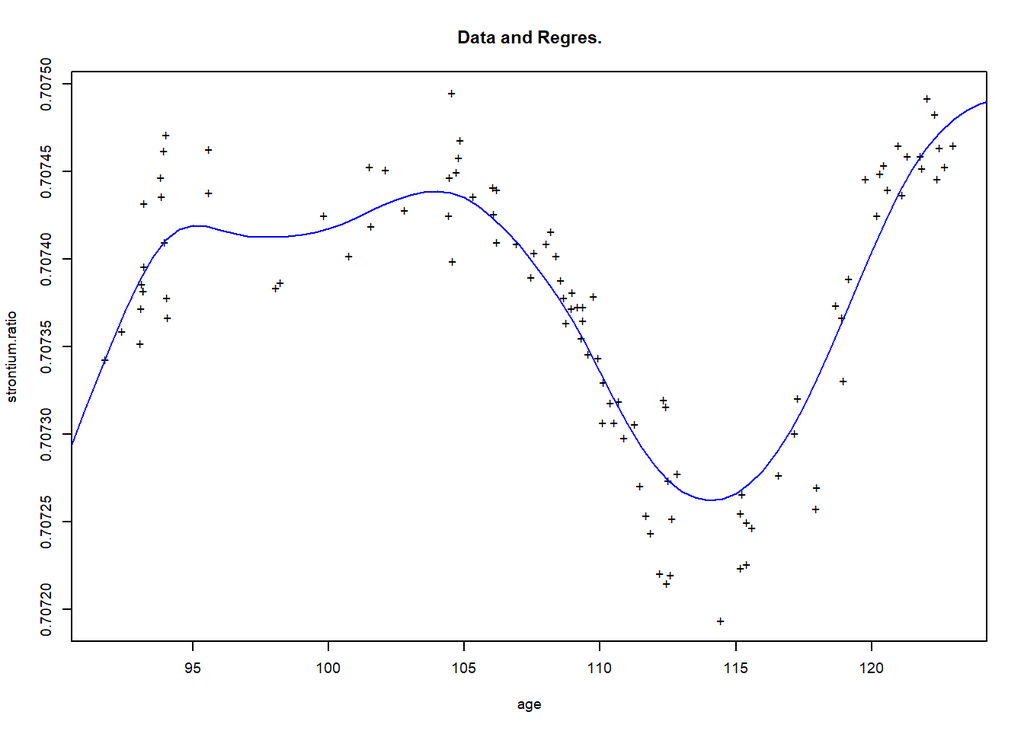

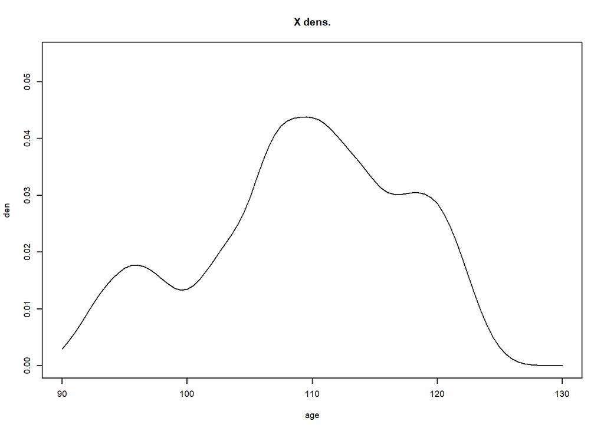

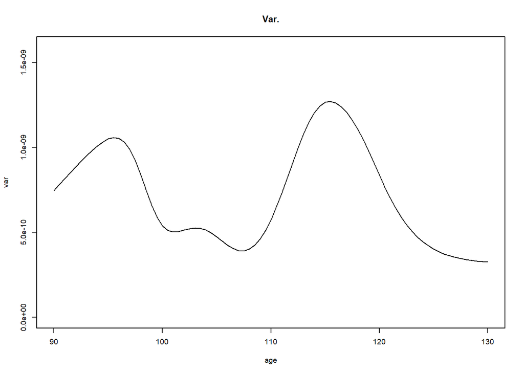

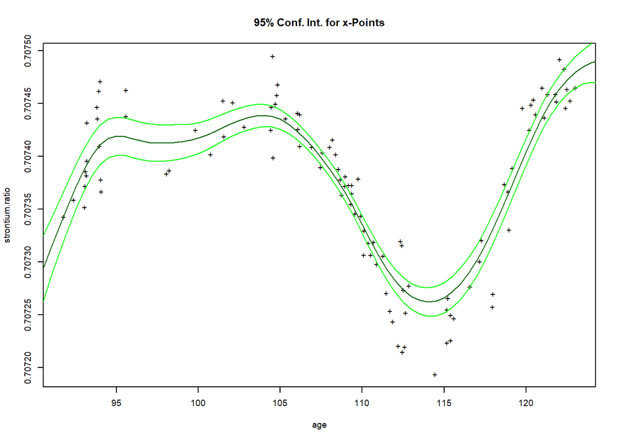

```r
plot(fit2a)
```

Let’s inspect the fitted object more closely

```r
names(fit2a)
```

```
##  [1] "bw"        "KName"     "kernel"    "deg"       "xeval"     "mf"
##  [7] "Y"         "X"         "weig"      "lpFit"     "CIwidth"   "residuals"
```

```r
fit2a$bw
```

```
## [1] 2
```

Does the result correspond to our manual implementation?

[figure not shown]

```r
age.grid<- seq(90, 130, by=0.5)
fit2<- my.ll.smoother(fossil$age, fossil$strontium.ratio, age.grid, h=2)
plot(fossil, main="h=2")
lines(fit2, col=2, lwd=3)
lines(fit2a$lpFit[1:2], lty=2, lwd=2)

legend(95,0.70730, c("our function", "locpol" ), lwd=c(3,2), lty=c(1,2), col=c(1,2))
```

Yes, there is perfect agreement between the two implementations.

We can also do this for the `lidar` data:

```r
fitl2a<- locpol(logratio~range, bw=20, kernel=gaussK, data=lidar)
```

with associated plots

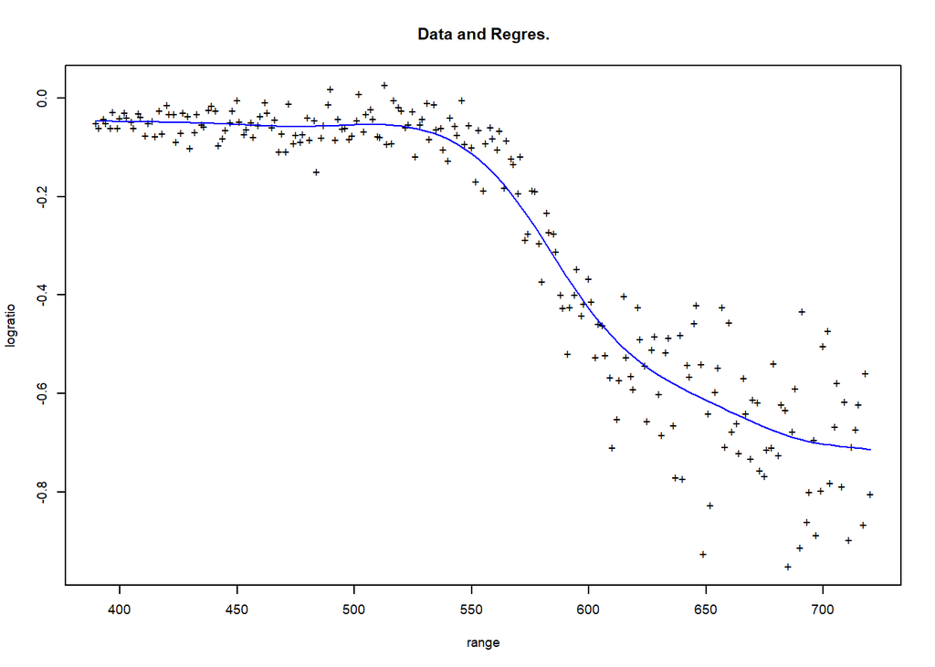

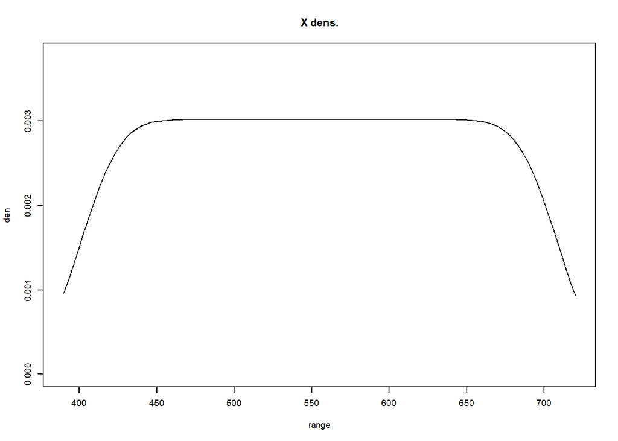

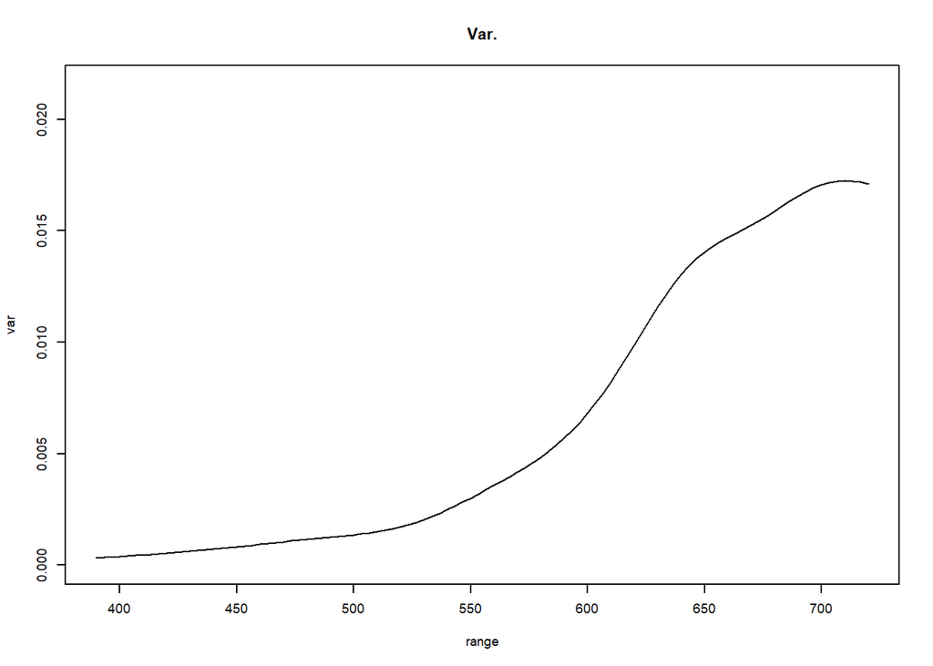

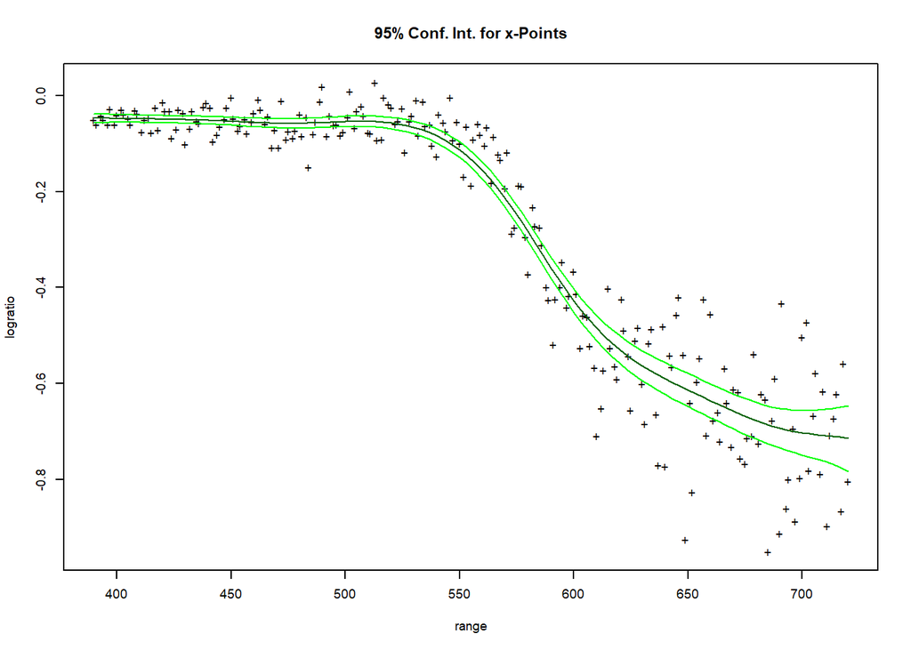

```r
plot(fitl2a)
```

Now let’s look into bandwidth selection. For the “rule-of-thumb”, we get:

```r
thumbBw(fossil$age, fossil$strontium.ratio, kernel=gaussK, deg=1)
```

```
## [1] 0.6231473
```

```r
thumbBw(lidar$range, lidar$logratio, kernel=gaussK, deg=1)
```

```
## [1] 4.178616
```

with resulting estimates:

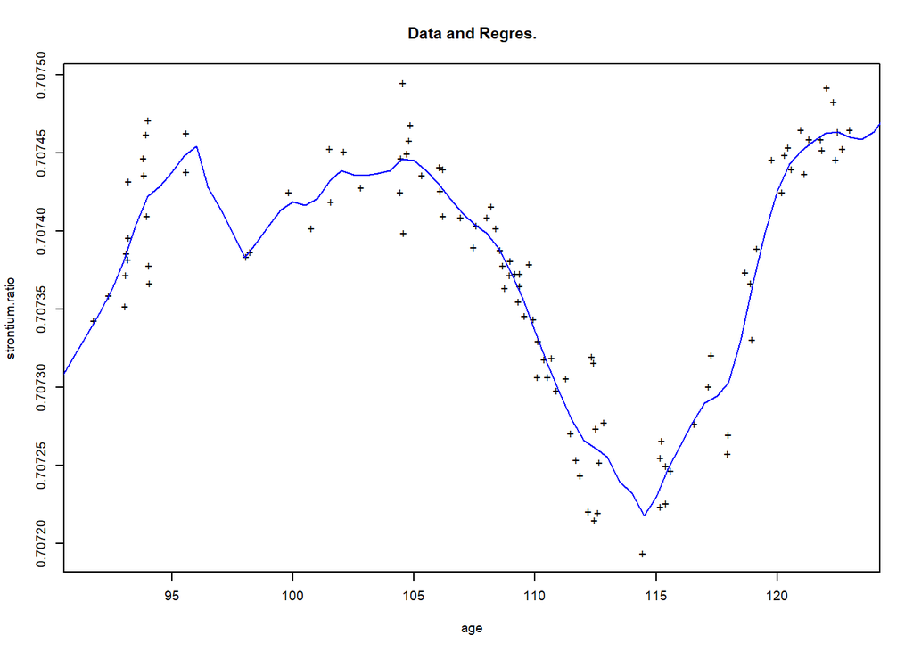

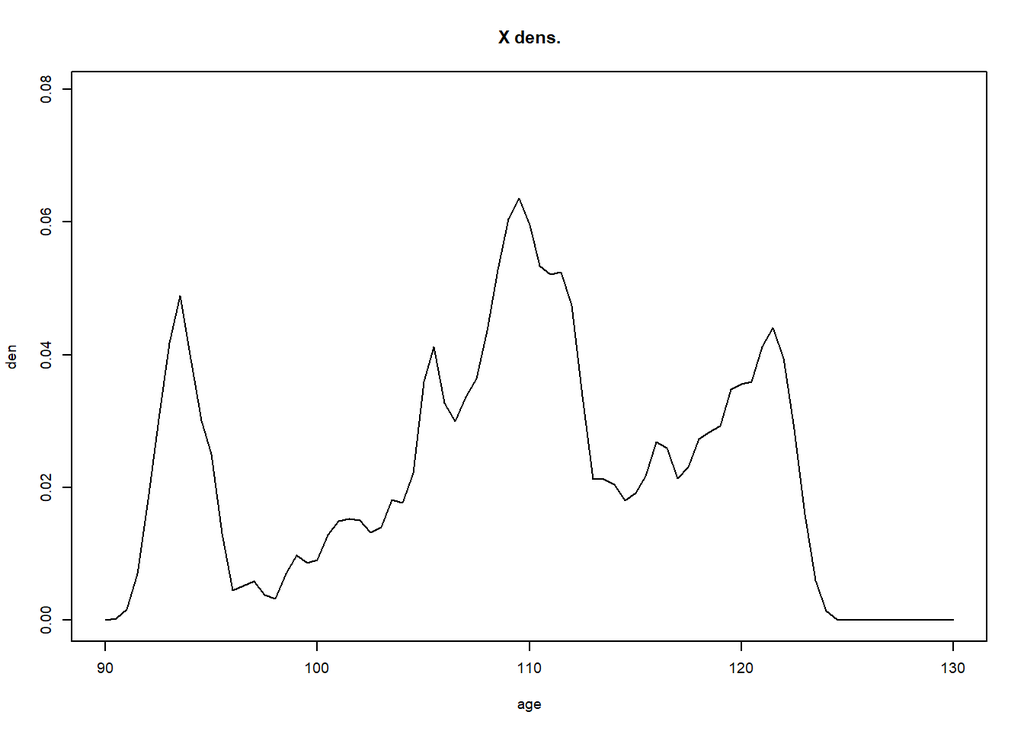

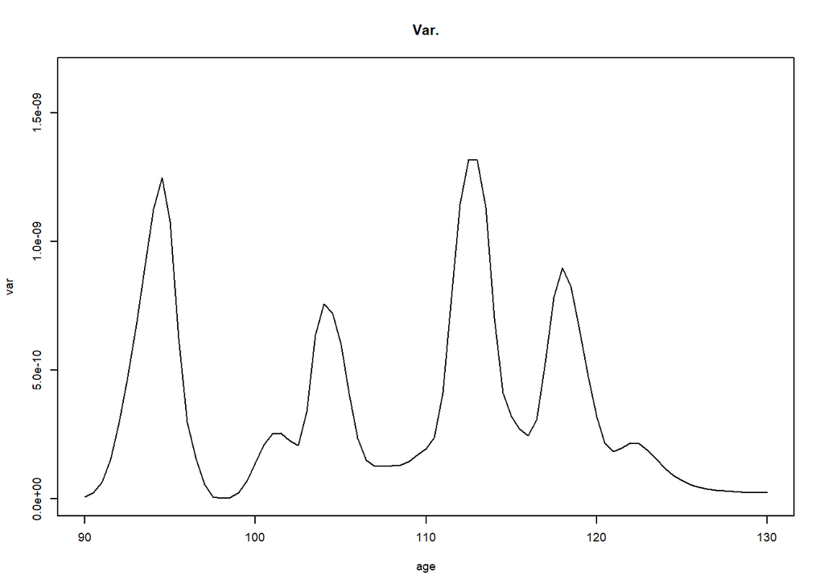

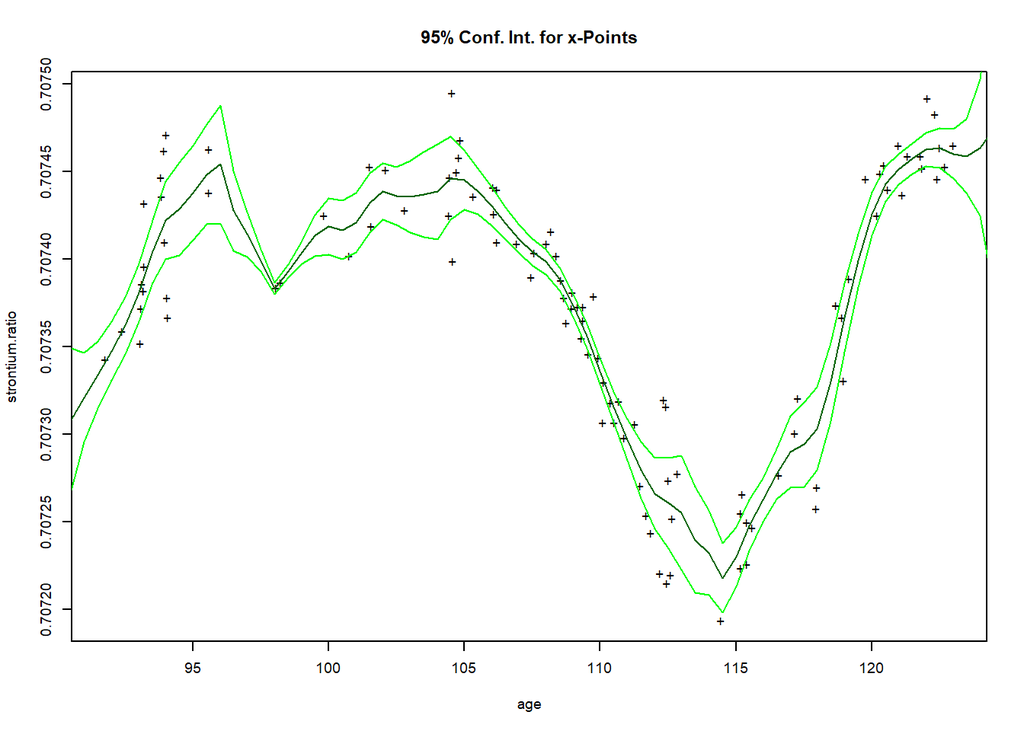

```r
fit2b<- locpol(strontium.ratio~age, bw=0.6232473, kernel=gaussK, xeval=age.grid,  data=fossil)
plot(fit2b)
```

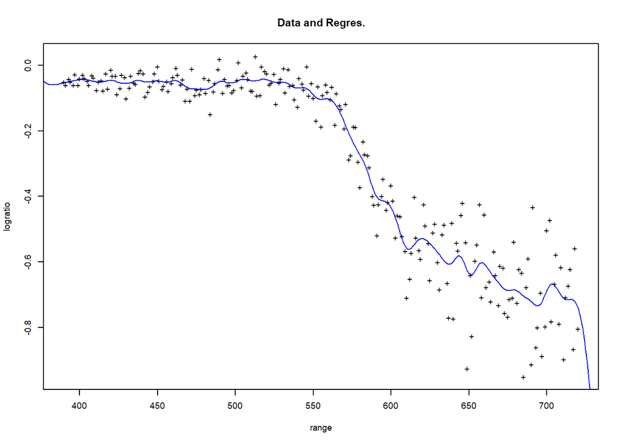

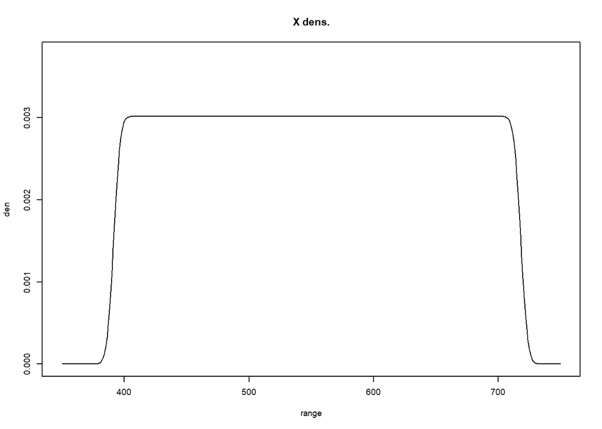

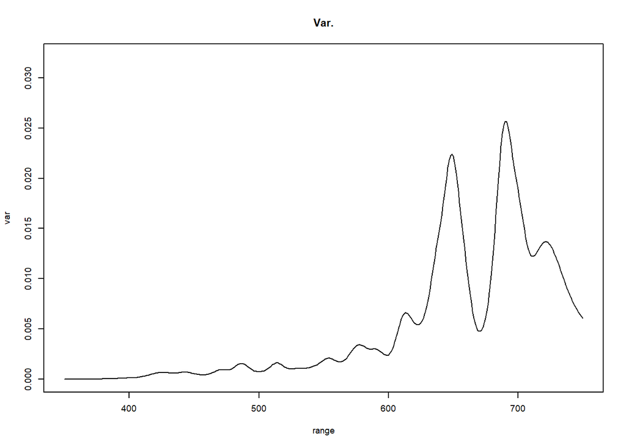

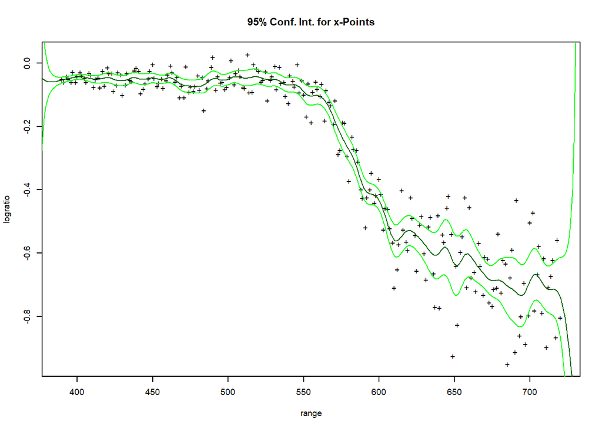

```r
fit2lb<- locpol(logratio~range, bw=4.1786, kernel=gaussK, xeval=range.grid,  data=lidar)
plot(fit2lb)
```

In both cases this seems to have settled on bandwidths which are rather too small. I would suspect that an underestimation of $\hat{\sigma}$ has played a role in both. Perhaps a full plug-in technique performs better? We find function `dpill` in R package `KernSmooth` ( “Least squares quartic fits over blocks of data are used to obtain an initial estimate.”):

```r
require(KernSmooth)
dpill(fossil$age, fossil$strontium.ratio)
```

```
## [1] 0.7875148
```

```r
dpill(lidar$range, lidar$logratio)
```

```
## [1] 16.20422
```

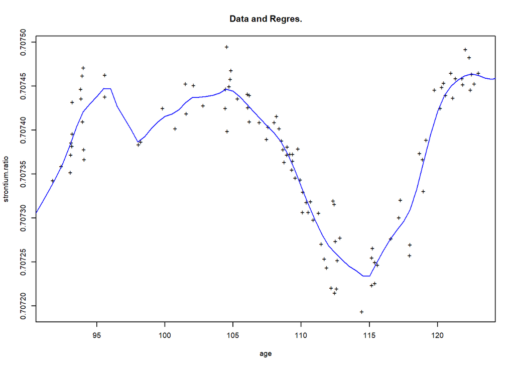

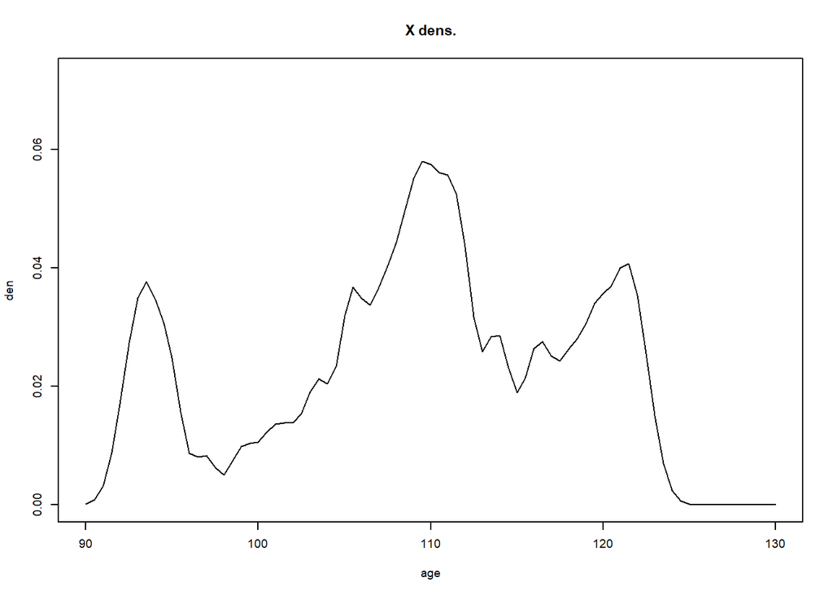

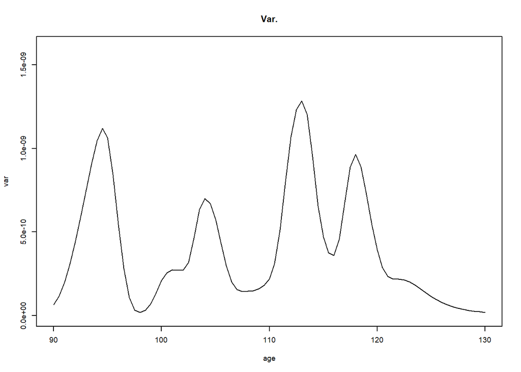

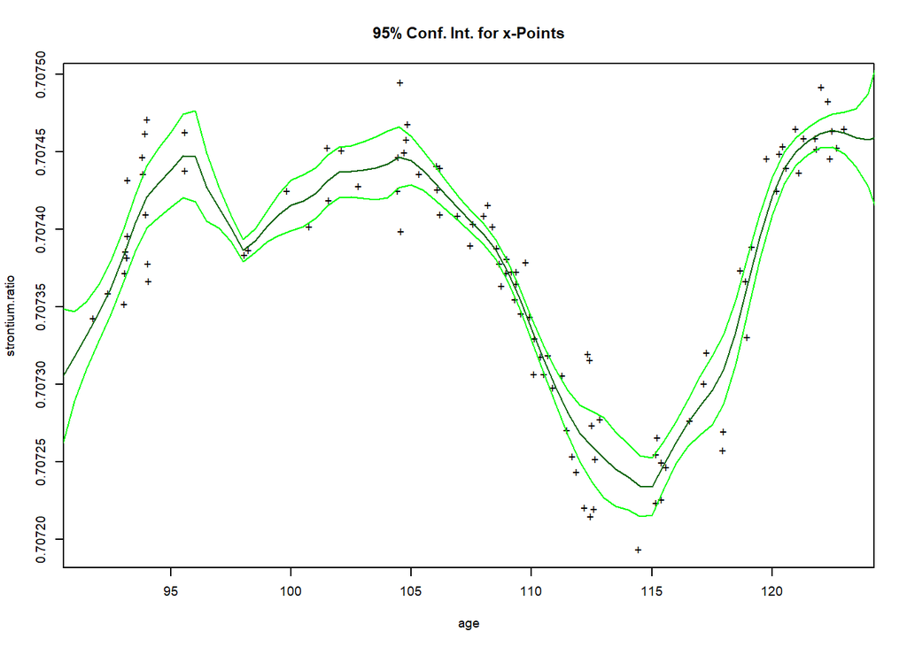

```r
fit2b<- locpol(strontium.ratio~age, bw=0.7875, kernel=gaussK, xeval=age.grid,  data=fossil)
plot(fit2b)
```

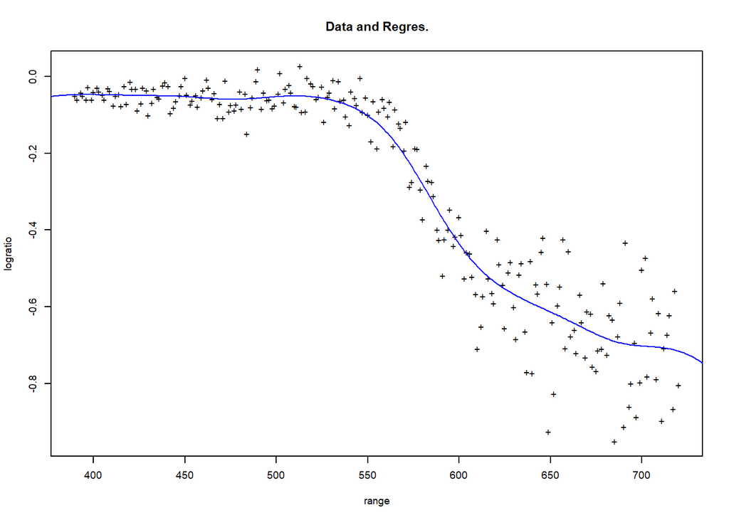

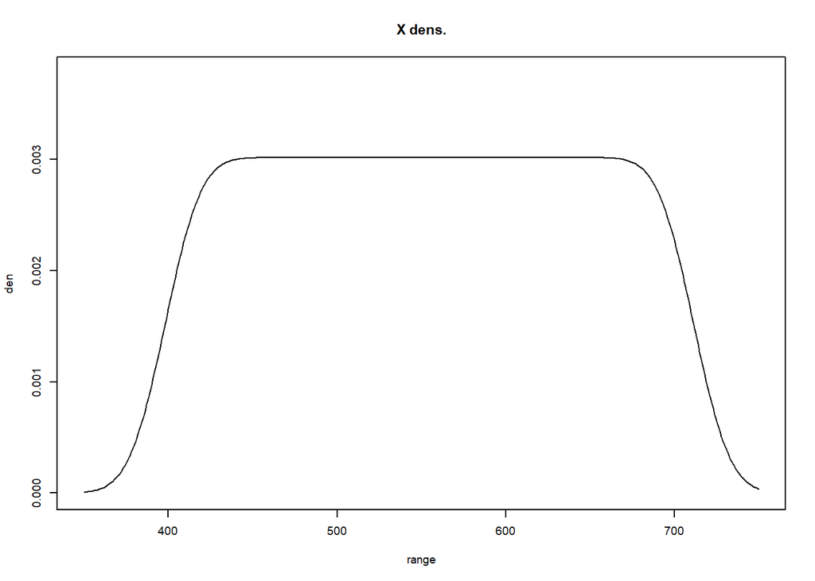

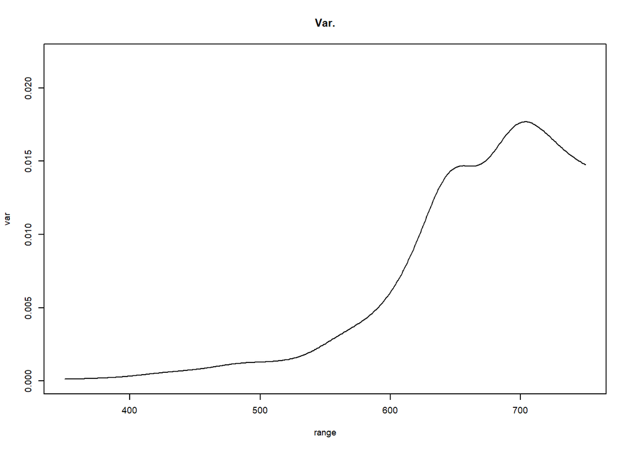

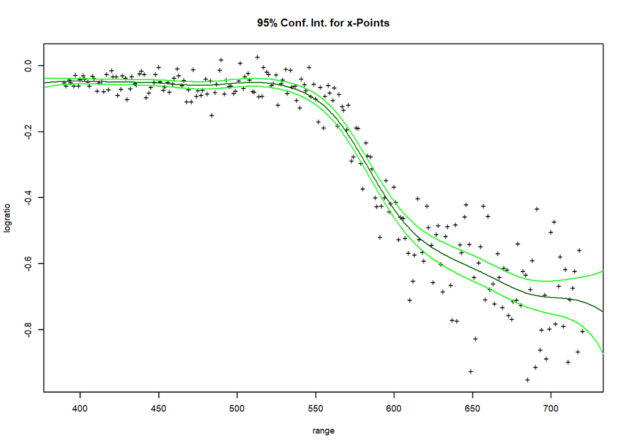

```r
fit2lb<- locpol(logratio~range, bw=16.204, kernel=gaussK, xeval=range.grid,  data=lidar)
plot(fit2lb)
```

Yes this is now a bit better. Note that the difference between the optimal bandwidths of the two approaches is larger for the `lidar` data, which are heteroscedastic, and hence may more likely deliver a poorly performing ROT bandwidth.

## 4.3 Multivariate local regression

We assume now that there are $d>1$ predictor variables, yielding data of type

$$(x_{i1}, \ldots, x_{id},y_i),\quad i=1, \ldots, n$$

where $x_{ij}$ is the $i$th observation from the $j$th predictor variable, for $j=1, \ldots, d$.

We are again interested in establishing how the response relates to the $d$ predictors. A fully nonparametric location-scale model in this context can be written as
$$y_i=m(x_{i1}, \ldots, x_{id})+\sigma(x_{i1}, \ldots, x_{id})\epsilon_i$$
where

$m: \mathbb{R}^d\longmapsto \mathbb{R}$ is a sufficiently smooth function (usually twice differentiable in all directions), $\sigma:\mathbb{R}^d\longmapsto \mathbb{R}$ is the scale function (that we will not pay much attention to), and $\epsilon_i$ are independent errors with $E(\epsilon_i)=0$ and $\mbox{Var}(\epsilon_i)=1$ (which are also independent of the predictors).

The task, as before, is to estimate the function m.

### 4.3.1 Multivariate locally constant fitting

A locally constant fit for multivariate data can be done through an obvious extension of the Nadaraya-Watson estimator. For $x \in \mathbb{R}^d$ and

$$x_i=\left(\begin{array}{c} x_{i1}\\ \vdots\\x_{id} \end{array}\right) \in \mathbb{R}^d,\quad i=1,\ldots,n$$

we have

$$\hat{m}_{NW, H}(x)= \frac{\sum_{i=1}y_iK_H(x_i-x)}{\sum_{i=1}K_H(x_i-x)}$$
where
$$K_H(z)= \frac{1}{|H|^{1/2}}K\left(H^{-1/2}z \right),\quad z \in \mathbb{R}^d,$$
and $K:\mathbb{R}^d\longmapsto \mathbb{R}$ is a d-variate kernel function with properties as defined in Section 3.4.1.

For instance, we could have a multivariate Gaussian kernel
$$K(u)=\frac{1}{(2\pi)^{d/2}}e^{-\frac{1}{2}u^Tu}$$
or, for any univariate kernel function, which for the purposes of this subsection we denote by $K_1(\cdot)$, a multivariate kernel is constructed as
$$K(u)=\prod_{j=1}^dK_1(u_j)$$
where $u=(u_1, \ldots, u_d)^T$.

So, the estimator $\hat{m}_{LL,H}(x)$ is again just a weighted mean of all observations, with those $x_i$ located closer to the target point $x$ gaining a larger kernel weight than those far away.

**Example 4.4**

In this example we consider bivariate local regression for the previously considered `soils` data.

Specifically, we consider the varable `pH` from this data set as response, and the variables `Mg` and `Ca` as predictors. For convenience of handling we create a reduced data set `SpH` which only contains these three variables.

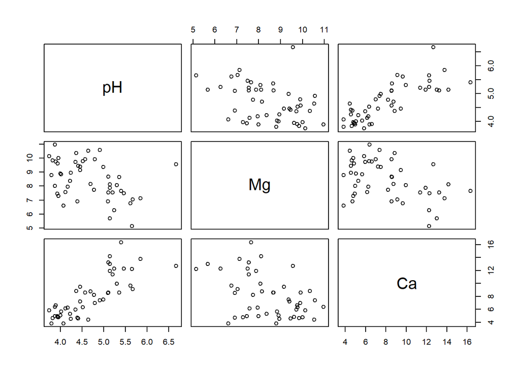

```r
require(carData)
require(scatterplot3d)
data(Soils)
SpH<- Soils[,c("pH", "Mg", "Ca")]
plot(SpH)
```

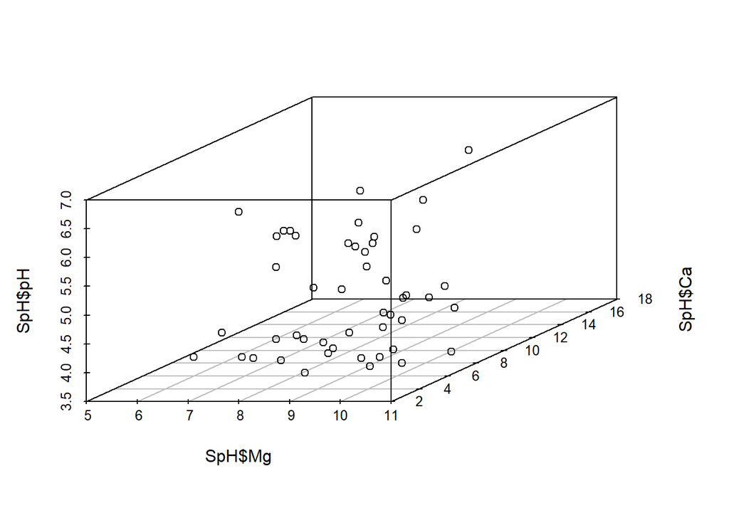

```r
scatterplot3d(x=SpH$Mg, y=SpH$Ca, z=SpH$pH)
```

We would like to find a nonparametric regression function which predicts `pH` as a function of `Mg` and `Ca`. So, here we have $d=2$,
$$H=\left(\begin{array}{cc} h_1^2 & \\ & h_2^2 \end{array}\right)$$
and let us write (with a slight abuse of notation) $x=(x_1, x_2)^T$. Then we can write (see similarly Ex 3.12)

$$K_H(x_i-x)= \frac{1}{|H|^{1/2}}K\left(H^{-\frac{1}{2}}(x_i-x) \right)= \frac{1}{h_1h_2}K_1\left(\frac{x_{i1}-x_1}{h_1} \right)\left(\frac{x_{i2}-x_1}{h_2} \right)$$
where we also see that the multipplicative constant $\frac{1}{h_1h_2}$ will cancel out between the numerator and denominator of $\hat{m}_{LL,H}(x)$. With this, we obtain an implementation of $\hat{m}_{LL,H}(x)$ as

```r
my.biv.kernel.smoother<- function(x1dat,x2dat, ydat, x1grid, x2grid, h1,h2){
  n<-length(ydat)
  G1<-length(x1grid)
  G2<-length(x2grid)
  est<-matrix(0,G1, G2)
  for (j in 1:G1){
    for (l in 1:G2){
  est[j,l]<-
     sum(ydat*my.kernel((x1dat-x1grid[j])/h1)*my.kernel((x2dat-x2grid[l])/h2))/
    sum(my.kernel((x1dat-x1grid[j])/h1)*my.kernel((x2dat-x2grid[l])/h2))
    }
  }
  return(c("x1grid"=list(x1grid), "x2grid"=list(x2grid), "yhat"=list(est)) )
}
```

where `my.kernel` stems from the early parts of this term and should be set to “Gaussian” for the purposes of this section. Then we set up our estimation grid

```r
summary(soils$Mg)
```

```
##    Min. 1st Qu.  Median    Mean 3rd Qu.    Max.
##   5.150   7.537   8.515   8.465   9.648  10.960
```

```r
summary(soils$Ca)
```

```
##    Min. 1st Qu.  Median    Mean 3rd Qu.    Max.
##   3.820   5.040   7.305   8.029   9.735  16.350
```

```r
Mg.grid<- seq(4,12, by=0.2)
Ca.grid<- seq(3,18, by=0.2)
```

and proceed with the actual estimation (using $h_1=h_2=1$)

```r
soil.estimate<- my.biv.kernel.smoother(
  x1dat=SpH$Mg,
  x2dat=SpH$Ca,
  y=SpH$pH,
  x1grid=Mg.grid,
  x2grid=Ca.grid,
  h1=1,
  h2=1
  )
```

We can visualize the resulting estimator via

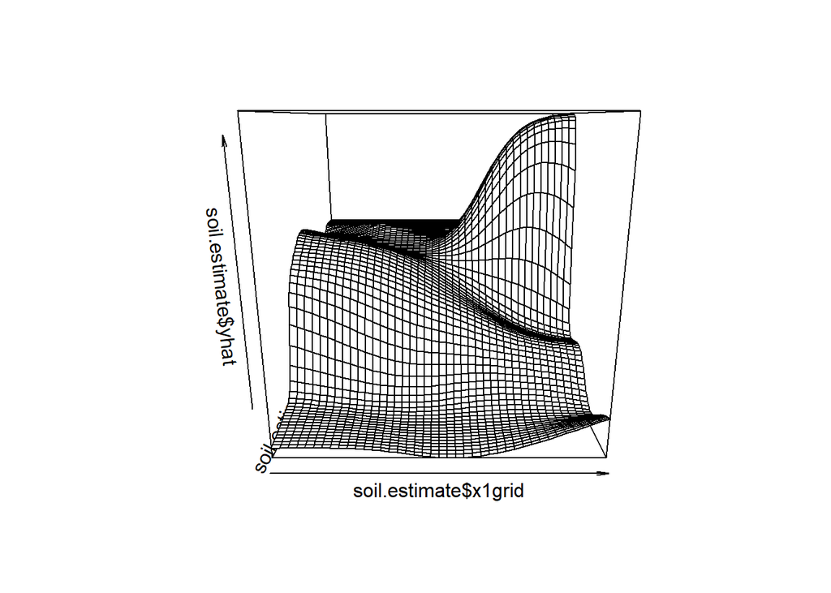

```r
persp(soil.estimate$x1grid, soil.estimate$x2grid, soil.estimate$yhat )
```

There does exist a function for bivariate locally constant regression in R package `locpol` with which we may want to compare:

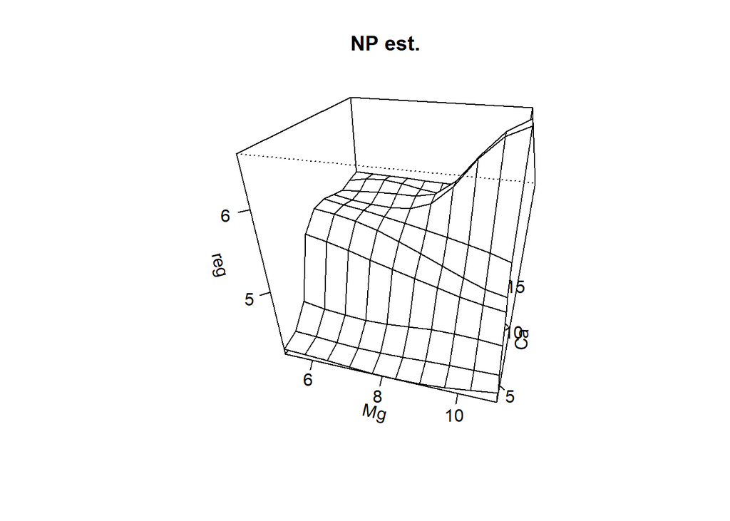

```
##            Mg        Ca      den
## 1    5.150000  3.820000 4.122082
## 2    5.795556  3.820000 4.112766
## 3    6.441111  3.820000 4.094727
## 4    7.086667  3.820000 4.069125
## 5    7.732222  3.820000 4.046931
## 6    8.377778  3.820000 4.044557
## 7    9.023333  3.820000 4.063343
## 8    9.668889  3.820000 4.095733
## 9   10.314444  3.820000 4.140457
## 10  10.960000  3.820000 4.197691
## 11   5.150000  5.212222 4.148143
## 12   5.795556  5.212222 4.126309
## 13   6.441111  5.212222 4.102873
## 14   7.086667  5.212222 4.084642
```

[output cut: 86 more lines]

```r
require(locpol)
#?bivReg
soil.estimate2<- bivReg(SpH[,c(2,3)],SpH[,1], K=gauK2d, H=diag(c(1^2, 1^2)) )
plot(soil.estimate2)
```

This does look similar but not necessarily the same. Let us try to adjust the angles from which we look at this:

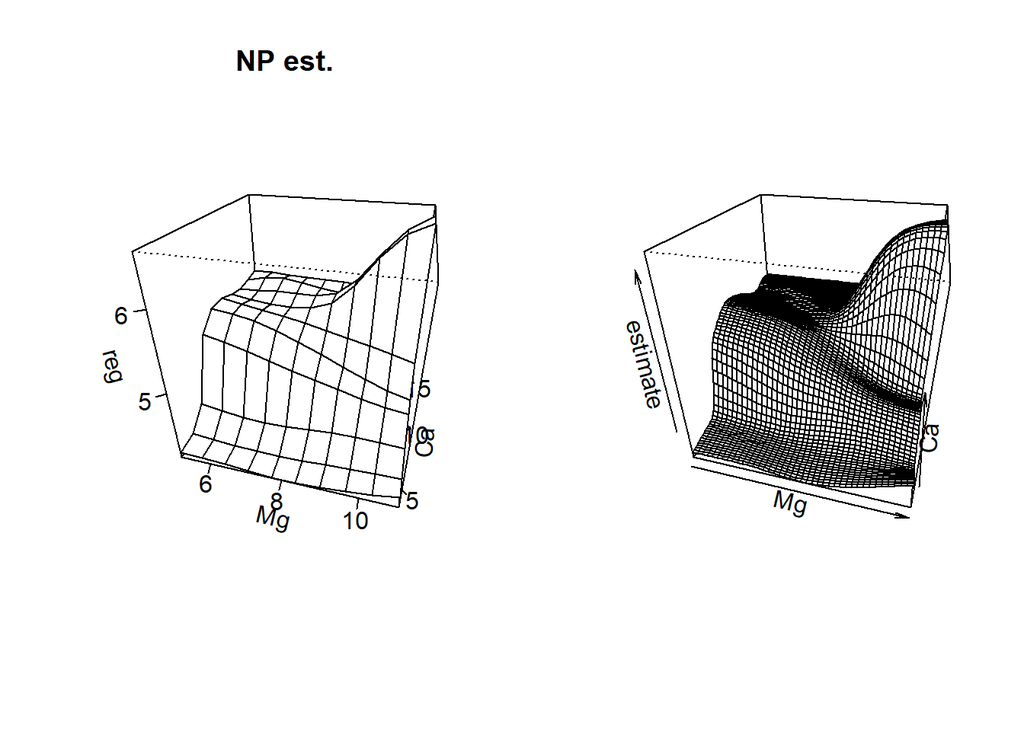

```r
par(mfrow=c(1,2))
plot(soil.estimate2)
persp(soil.estimate$x1grid, soil.estimate$x2grid, soil.estimate$yhat, phi=30, theta=15, xlab="Mg", ylab="Ca", zlab="estimate" )
```

This might be the same. Note that the resolution of the output of `bivReg` is not great, and that there does not seem to be a way of adjusting this.

### 4.3.2 Multivariate local linear regression

Consider a first-order Taylor expansion of $m:\mathbb{R}^d\longmapsto \mathbb{R}$ around the target point $x \in \mathbb{R}^d$:

$$m(z)= m(x)+\nabla m(x)^T(z-x)+ \ldots...$$
where the $\nabla$ operator is defined as
$$\nabla=\left(\frac{\partial}{\partial x_1}, \ldots, \frac{\partial}{\partial x_d}\right)^T$$
Now identify $\beta_0\equiv m(x)$ and

$$\nabla m(x)\equiv \beta_1= \left(\begin{array}{c} \beta_{11} \\ \vdots \\\beta_{1d} \end{array}\right)$$
This motivates the estimator
$$\hat{m}_{LL,H}(x)= \hat{\beta}_0$$
where $\left(\begin{array}{c} \beta_0 \\ \beta_1 \end{array}\right)\in \mathbb{R}^{p+1}$ is found by minimizing
$$Q(\beta_0, \beta_1)= \sum_{i=1}^nK_H(x_i-x)\left(y_i-\beta_0-\beta_1^T(x_i-x) \right)^2$$
which with

$$W_H= \left(\begin{array}{ccc}K_H(x_1-x) & & \\
& \ddots & \\
& & K_H(x_n-x)
\end{array}\right) \in \mathbb{R}^{n \times}, \quad
X_d= \left(\begin{array}{cc}
1 & (x_1-x)^T\\
\vdots & \vdots \\
1 & (x_n-x)^T\\
\end{array}\right) \in \mathbb{R}^{n \times d+1}$$
gives

$$\hat{\beta}_0= e_1^T (X_dW_HX_d)^{-1}X_d^TW_HY.$$

Some notes on this estimator:

- The asymptotic bias and variance of $\hat{m}_{LL,H}(x)$ have been developed (Wand & Jones, 1995, p. 140, Fan & Gijbels, 1996 p.301), showing similar bias-reducing properties as in the univariate case.
- Optimal bandwidth matrices can in principle be derived based on this concept (Fan & Gijbels, 1996, p. 302, and several journal papers)
- To my knowledge, there does not exist a straightforward, “pure”, publicly available implementation of $\hat{\beta}_0$. The closest calls are R functions `loess` and `npreg` which are however somewhat engineered.
- **The curse of dimensionality is hitting here as well!**
- Eventually, the more useful modelling approach is to consider *additive models*,

$$y_i=\beta_0+m_1(x_{i1})+ \ldots +m_p(x_{ip})+ \mbox{error}$$

where $m_j:\mathbb{R}\longmapsto \mathbb{R}$ are each estimated by usual, univariate smoothers.

## 4.4 Additive models

Recall the $d$-variate nonparametric regression model
$$y_i=m(x_{i1}, \ldots, x_{id})+\sigma(x_{i1}, \ldots, x_{id})\epsilon_i$$
where the $\epsilon_i$ are iid (and also independent from the predictors) with $E(\epsilon_i)=0$ and $\mbox{Var}(\epsilon_i)=1$.

Consider now the $y_i$ as realizations of a random variable $Y$ and the $x_{i1}, \ldots, x_{id}$ as realizations of random variables $X_1, \ldots, X_d$, respectively. Then we can rewrite the model as
$$E(Y|X_1, \ldots, X_d)= m(X_1, \ldots, X_d)$$
Differently to previous sections, we make now the conditional expectation notationally explicit. (That is, in this section 4.4, when no condition is given in the expectation, the expectation is *not conditional*!)

To avoid the curse of dimensionality for the $d$-variate nonparametric regression estimator, we consider an approximated version of the model displayed above, namely

$$E(Y|X_1, \ldots, X_d)= \beta_0+m_1(X_1)+ \ldots +m_d(X_d)$$
with smooth functions $m_j:\mathbb{R}\longrightarrow \mathbb{R}$, $z\longmapsto m_j(z)$, $j=1, \ldots, d$.

Is this model well-defined? To answer this, consider an alternative model where we have

$$\begin{align}
\tilde{m}_1(z)&= m_1(z)-c\\
\tilde{m}_2(z)&= m_2(z)+c\\
\tilde{m}_j(z)&=m_j(z)\quad \mbox{for } j=3, \ldots, d
\end{align}$$
where $d\ge 3$ and $c>0$. Then clearly

$$\sum_{j=1}^dm_j(z)=\sum_{j=1}^d \tilde{m}_j(z)$$
so the model is not identifiable. Therefore, in the additive model, all the $d$ functions are assumed to be mean-centered, i.e.

$$E_{X_j}(m_j(X_j))= \int m_j(z)f_{X_j}(z)\,dz=0$$
where $f_{X_j}(z)$ is the density of $X_j$. (This assumption can be made without loss of generality, and in order to do this we do not need to know the densities $f_{X_j}$ or the ``un-centered” means of the functions $m_j$. The model will implicitly be estimated under this assumption, and we are only interested in the shapes of the trends anyway.)

Note that by the theorem of iterated expectation, for two random variables $X$ and $Y$, one has $E(Y)= E_X(E(Y|X))$. This implies then, for the unconditional(!) response $Y$ of our nonparametric, additive model,

$$\begin{align}
E(Y)&= E_{X_1, \ldots, X_d}\left(Y|X_1, \ldots, X_d \right)\\
&= E_{X_1, \ldots, X_d}\left(\beta_0+m_1(X_1)+ \ldots +m_d(X_d) \right)\\
&= \beta_0+ E_{X_1, \ldots, X_d}(m_1(X_1))+ \ldots + E_{X_1, \ldots, X_d}(m_d(X_d))\\
&= \beta_0 +E_{X_1}(m_1(X_1))+ \ldots + E_{X_d}(m_d(X_d))\\
&= \beta_0
\end{align}$$
So we have immediately the estimator

$$\hat{\beta}_0= \frac{1}{n}\sum_{i=1}^n y_i$$

To estimate the functions $m_j$, note that we can write

$$\begin{align}
E(Y|X_1, \ldots, X_d)- \beta_0-\sum_{\ell \not=j}^dm_{\ell}(X_{\ell})
&=m_j(X_j)\\
E\left(Y-\beta_0- \sum_{\ell \not=j}^dm_{\ell}(X_{\ell}) | X_1, \ldots, X_d\right)
&=m_j(X_j)
\end{align}$$

Therefore, considering the content of the large bracket as a “working response”, for known $\beta_0$ and functions $m_{\ell}$, $\ell \not= j$, the function $m_j$ can be estimated. By cycling over $j$ this idea leads to the **Backfitting Algorithm**:

1. Initialize $\hat{\beta}_0= \frac{1}{n}\sum_{i=1}^n y_i$, $\hat{m}_j^{[0]}\equiv 0$, $j=1, \ldots, d$, where the notation $[s]$ stands for `iteration cycle’.
2. For $j=1, \ldots, d$, and iteration $s\ge 1$, cycle
   $$r_i= y_i-\hat{\beta}_0- \sum_{\ell=1}^{j-1}\hat{m}_{\ell}^{[s]}(x_{i\ell})- \sum_{\ell=j+1}^d\hat{m}^{[s-1]}_{\ell}(x_{i\ell})$$
   where $\hat{m}_{\ell}^{[s]}(x_{i\ell})$ corresponds to terms which have already been updated in the $s$-th cycle, and $\hat{m}^{[s-1]}_{\ell}(x_{i\ell})$ corresponds to terms which haven’t. Then $m_j^{[s]}$ is estimated by fitting the model
   $$r_i=m_j(x_{ij})+\tilde{\epsilon}_{ij}$$
   to pairs $(r_i, x_{ij})$, $i=1, \ldots,n$, where $(\tilde{\epsilon}_{ij})$ is some iid error term with mean zero, which is a usual, one-dimensional nonparametric regression problem. Any nonparametric estimator can be used for this, such as the Nadaraya-Watson or local linear estimators. We do this until
3. convergence is reached, which is usually established by verifying that the $\hat{m}_j^{[s]}$ stop changing over successive cycle indexes $s$.

**Example 4.5**

We use the R function `gam` in R package **gam**. This function implements the backfitting exactly as derived above, and does support local linear smoothing via the wrapper function `lo`. The implementation of this local linear estimator is based on the `loess` framework which is a slight variant of “our” local linear estimator which uses a `span` parameter (representing the proportion of data points in the neighboorhood of $x$ which are used for the estimation) rather than a fixed bandwidth, and a tricube kernel.

```r
require(gam)
```

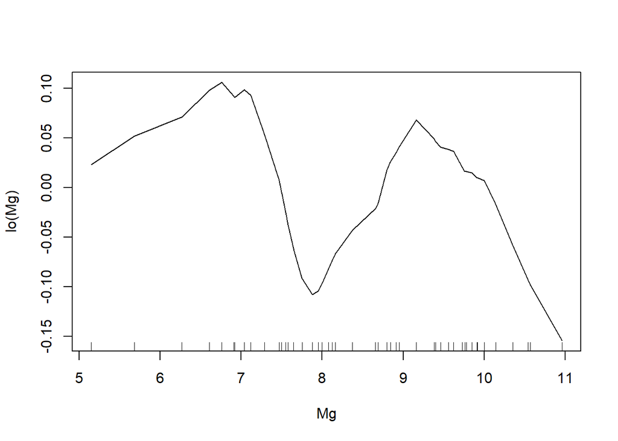

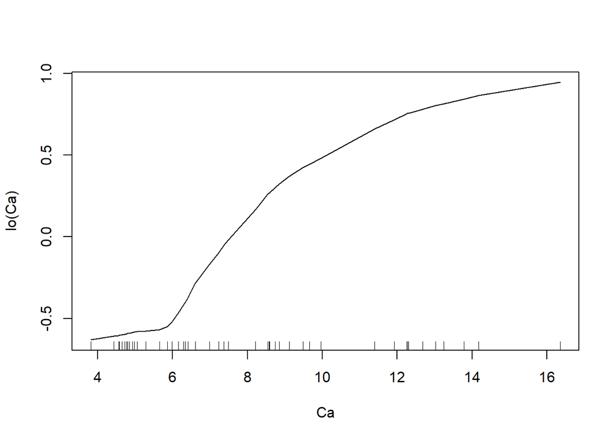

```r
require(carData)
data(Soils)
soil.gam2<-gam(pH~lo(Mg)+lo(Ca), data=Soils)
plot(soil.gam2)
```

We can change the span (default 0.5) to other values, and also plot (pointwise) confidence intervals:

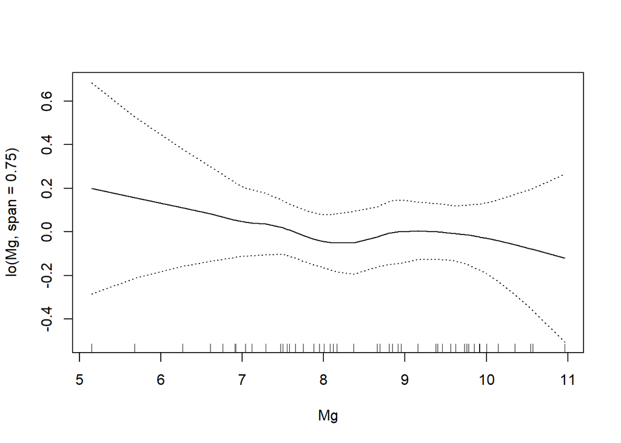

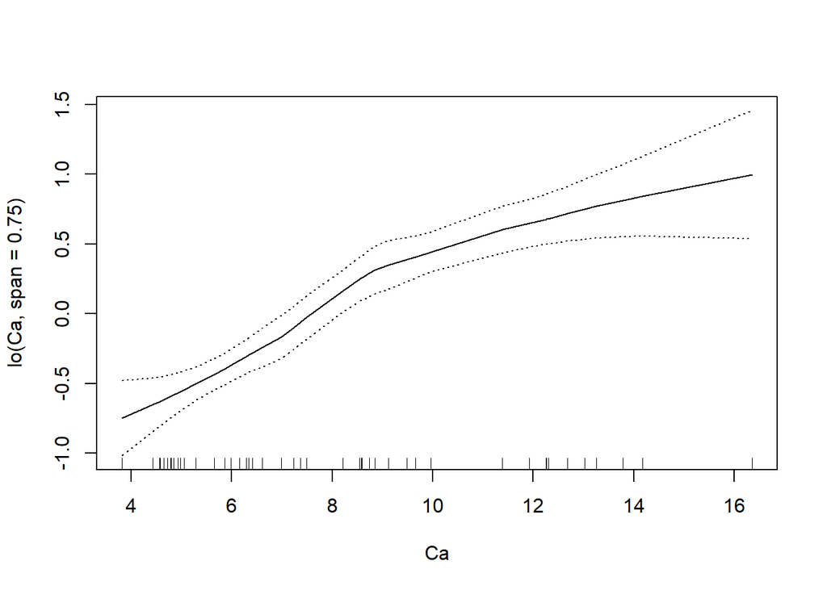

```r
soil.gam2a<-gam(pH~lo(Mg, span=0.75)+lo(Ca, span=0.75), data=Soils)
plot(soil.gam2a, se=TRUE)
```

This also works for larger numbers of predictors:

```r
soil.gam6<- gam(pH~lo(Ca)+lo(Na)+lo(Mg)+lo(P)+lo(N)+lo(K), data=Soils)
```

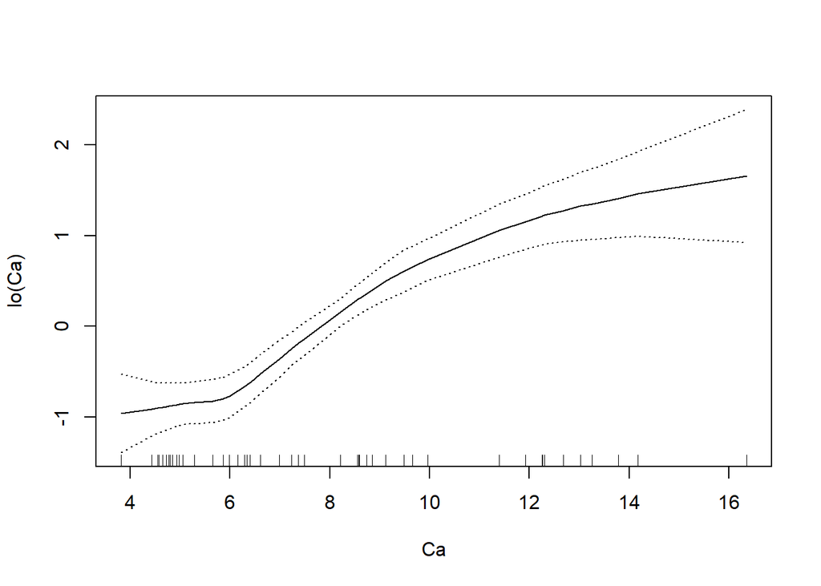

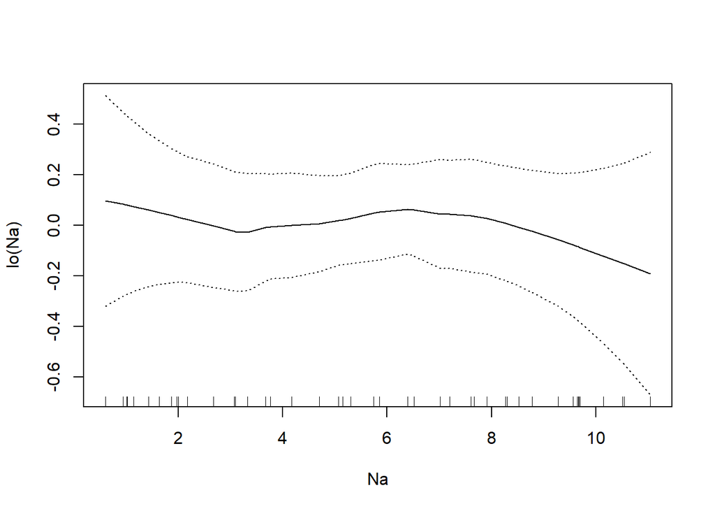

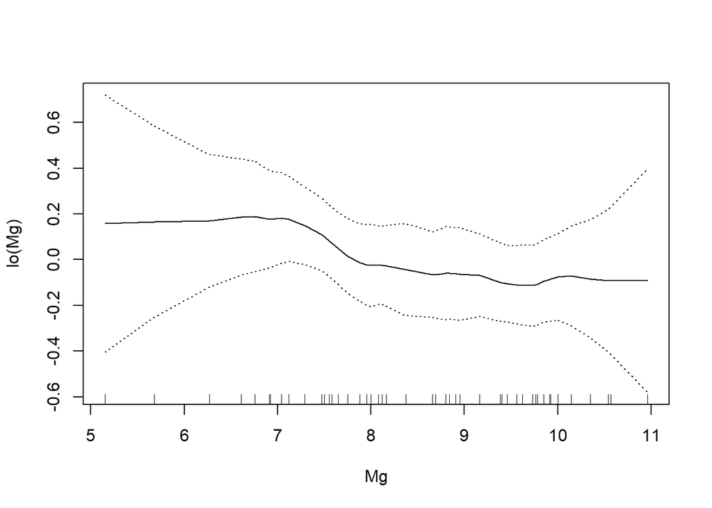

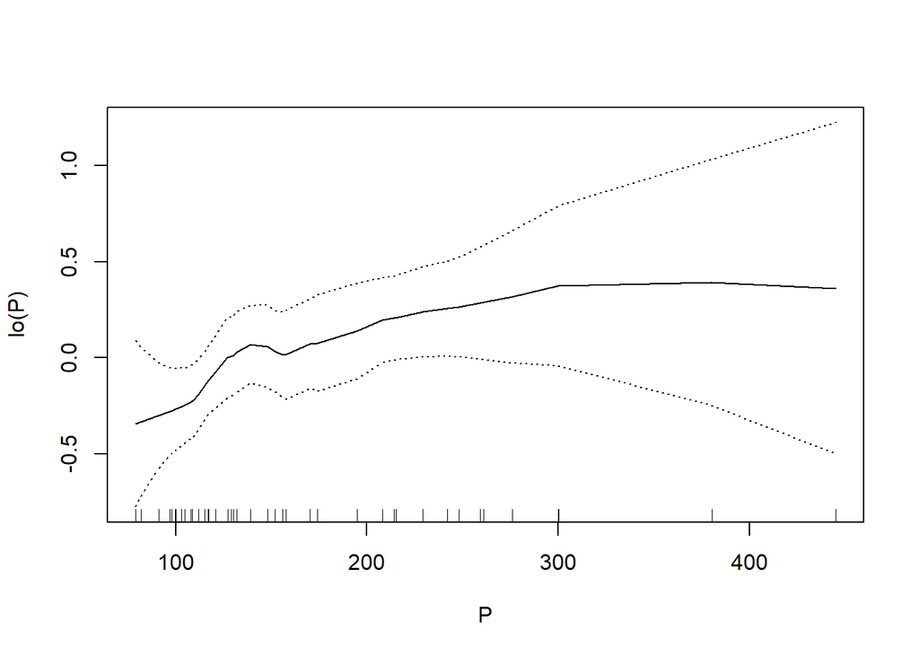

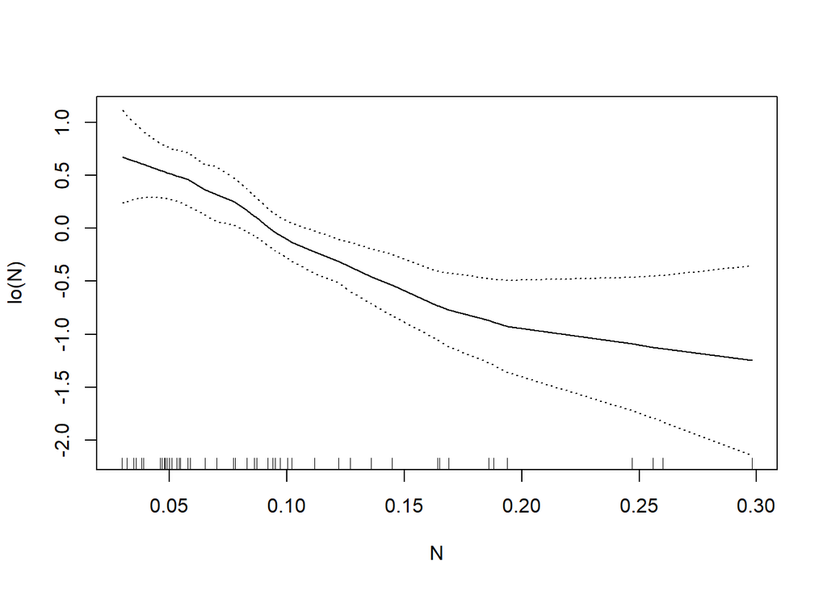

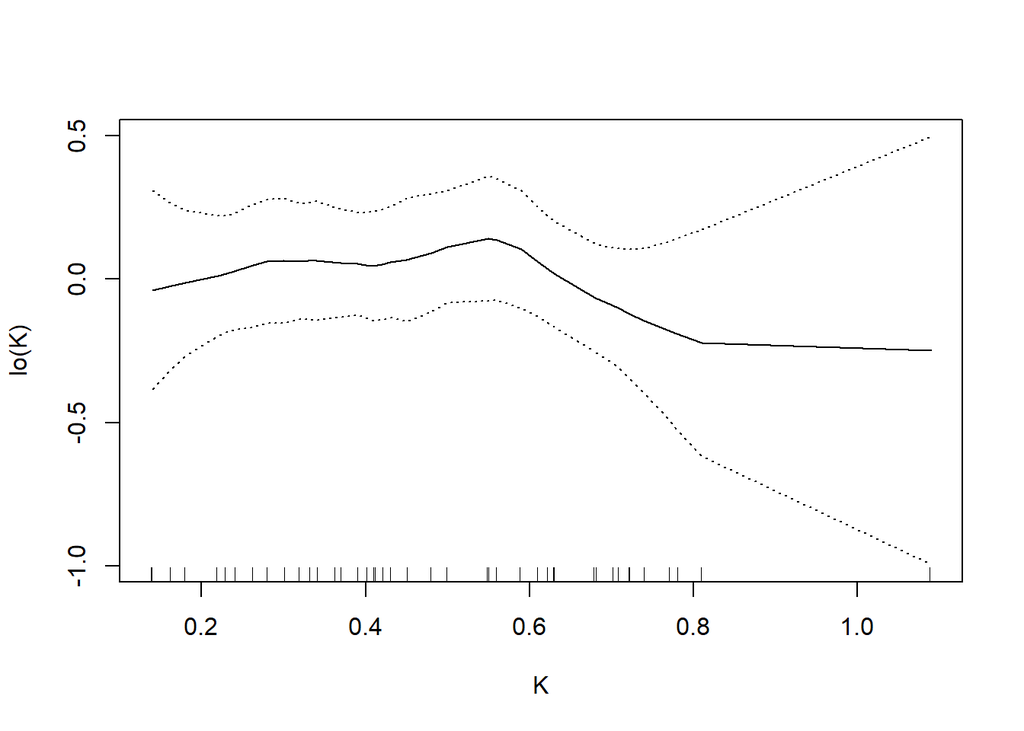

```r
plot(soil.gam6, se=TRUE)
```

```r
summary(soil.gam6)
```

```
##
## Call: gam(formula = pH ~ lo(Ca) + lo(Na) + lo(Mg) + lo(P) + lo(N) +
##     lo(K), data = Soils)
## Deviance Residuals:
##       Min        1Q    Median        3Q       Max
## -0.499466 -0.216506 -0.009361  0.213990  0.522473
##
## (Dispersion Parameter for gaussian family taken to be 0.135)
##
##     Null Deviance: 21.2153 on 47 degrees of freedom
## Residual Deviance: 3.1175 on 23.0939 degrees of freedom
## AIC: 56.7898
##
## Number of Local Scoring Iterations: NA
##
## Anova for Parametric Effects
##               Df  Sum Sq Mean Sq  F value    Pr(>F)
## lo(Ca)     1.000 14.8328 14.8328 109.8799 2.982e-10 ***
## lo(Na)     1.000  0.0000  0.0000   0.0000 0.9991789
## lo(Mg)     1.000  0.0897  0.0897   0.6648 0.4232095
## lo(P)      1.000  0.0332  0.0332   0.2460 0.6245605
## lo(N)      1.000  2.3331  2.3331  17.2833 0.0003778 ***
## lo(K)      1.000  0.0499  0.0499   0.3699 0.5489880
## Residuals 23.094  3.1175  0.1350
## ---
## Signif. codes:  0 '***' 0.001 '**' 0.01 '*' 0.05 '.' 0.1 ' ' 1
##
## Anova for Nonparametric Effects
##             Npar Df Npar F   Pr(F)
## (Intercept)
## lo(Ca)          2.7 4.2311 0.01841 *
## lo(Na)          2.3 0.3946 0.70327
## lo(Mg)          3.1 0.3870 0.76775
## lo(P)           3.4 1.0840 0.38096
## lo(N)           3.1 1.2676 0.30914
## lo(K)           3.4 0.8246 0.50530
## ---
## Signif. codes:  0 '***' 0.001 '**' 0.01 '*' 0.05 '.' 0.1 ' ' 1
```

The `summary` output describes two types of significances: The “Anova for Parametric Effects” establishes whether the term as a whole is needed (whether parametric or nonparametric), and the “Anova for Nonparametric Effects” establishes whether there is evidence that the nonparametric term should be preferred over the parametric one. Note that this is ANOVA-based so depends on the order of inclusion. Another useful technique to assess the relevance of the individual terms is to look at the curve plots with the confidence intervals.

- if you can lay a horizontal line through the confidence intervals, the entire term may not be needed
- if you can lay *any* line through the confidence intervals, the nonparametric term may not be needed (but still the linear one)

If you mix and match parametric and nonparametric terms, you get a **semiparametric model**:

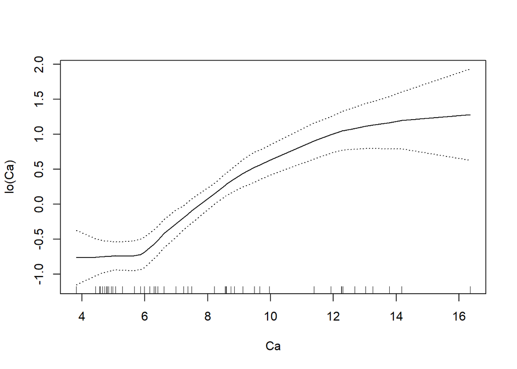

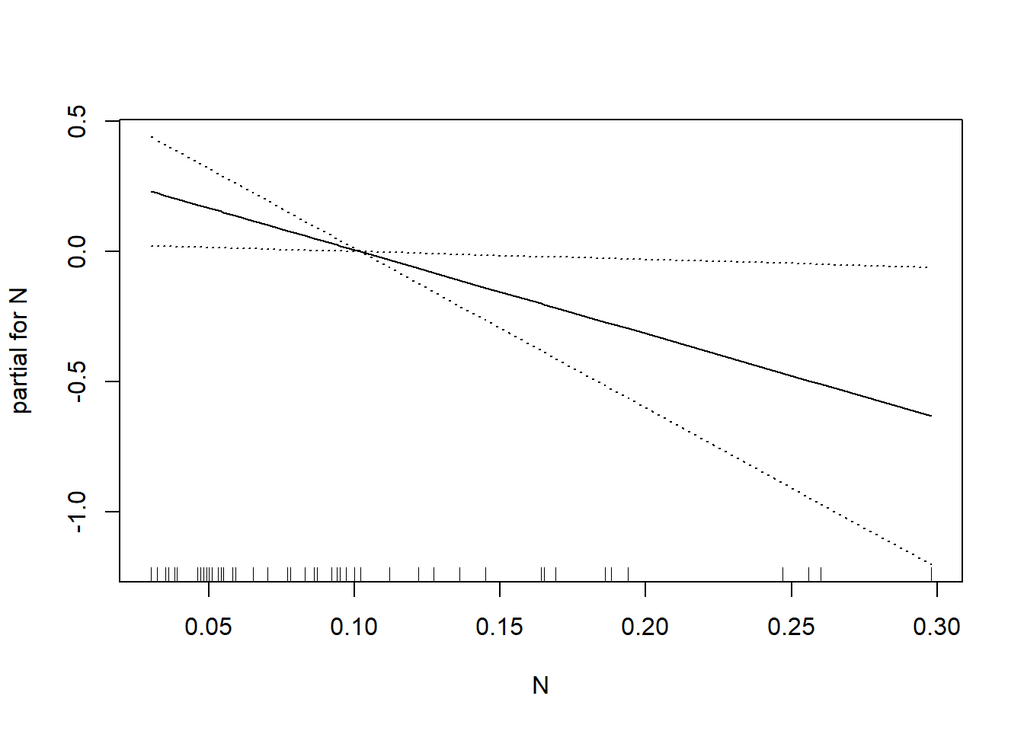

```r
soil.gam.reduced<- gam(pH~lo(Ca)+N, data=Soils)
plot(soil.gam.reduced, se=TRUE)
```

```r
summary(soil.gam.reduced)
```

```
##
## Call: gam(formula = pH ~ lo(Ca) + N, data = Soils)
## Deviance Residuals:
##       Min        1Q    Median        3Q       Max
## -0.702791 -0.233828 -0.008408  0.229444  0.857314
##
## (Dispersion Parameter for gaussian family taken to be 0.1245)
##
##     Null Deviance: 21.2153 on 47 degrees of freedom
## Residual Deviance: 5.2626 on 42.2822 degrees of freedom
## AIC: 43.5459
##
## Number of Local Scoring Iterations: NA
##
## Anova for Parametric Effects
##               Df  Sum Sq Mean Sq  F value    Pr(>F)
## lo(Ca)     1.000 13.8723 13.8723 111.4568 1.996e-13 ***
## N          1.000  0.6074  0.6074   4.8802   0.03264 *
## Residuals 42.282  5.2626  0.1245
## ---
## Signif. codes:  0 '***' 0.001 '**' 0.01 '*' 0.05 '.' 0.1 ' ' 1
##
## Anova for Nonparametric Effects
##             Npar Df Npar F    Pr(F)
## (Intercept)
## lo(Ca)          2.7 5.5649 0.003416 **
## N
## ---
## Signif. codes:  0 '***' 0.001 '**' 0.01 '*' 0.05 '.' 0.1 ' ' 1
```

Note there exist other smoothers which you can use….

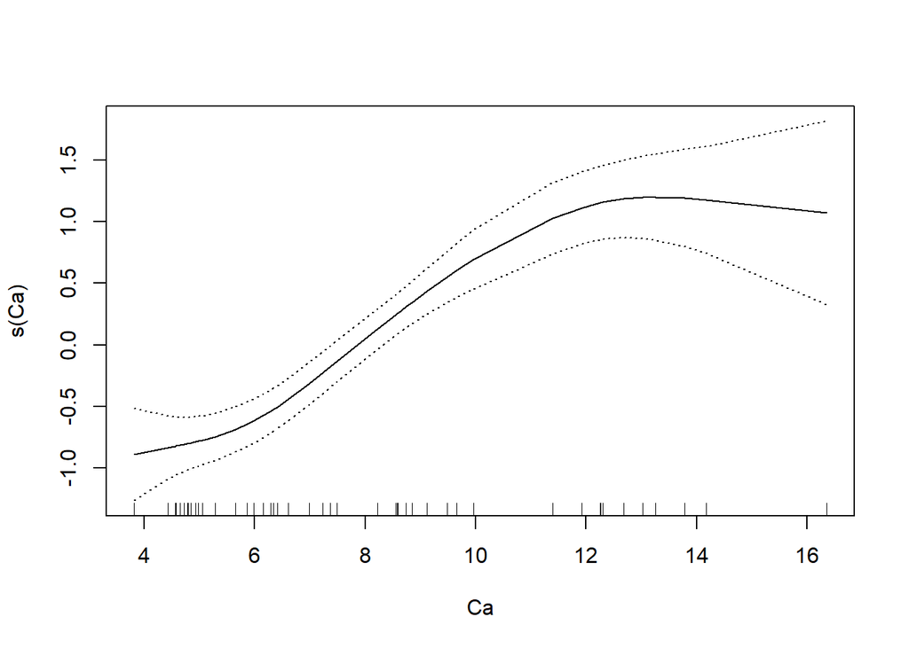

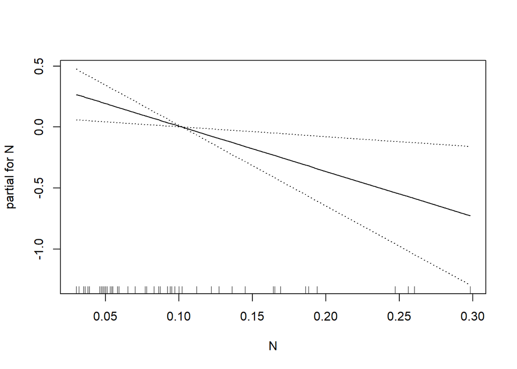

```r
soil.gam.reduced<- gam(pH~s(Ca)+N, data=Soils)
plot(soil.gam.reduced, se=TRUE)
```

```r
summary(soil.gam.reduced)
```

```
##
## Call: gam(formula = pH ~ s(Ca) + N, data = Soils)
## Deviance Residuals:
##      Min       1Q   Median       3Q      Max
## -0.72518 -0.20404 -0.02767  0.19568  0.74505
##
## (Dispersion Parameter for gaussian family taken to be 0.1233)
##
##     Null Deviance: 21.2153 on 47 degrees of freedom
## Residual Deviance: 5.1791 on 42 degrees of freedom
## AIC: 43.3426
##
## Number of Local Scoring Iterations: NA
##
## Anova for Parametric Effects
##           Df  Sum Sq Mean Sq  F value    Pr(>F)
## s(Ca)      1 13.8723 13.8723 112.4977 1.879e-13 ***
## N          1  0.8079  0.8079   6.5515   0.01417 *
## Residuals 42  5.1791  0.1233
## ---
## Signif. codes:  0 '***' 0.001 '**' 0.01 '*' 0.05 '.' 0.1 ' ' 1
##
## Anova for Nonparametric Effects
##             Npar Df Npar F   Pr(F)
## (Intercept)
## s(Ca)             3 5.3143 0.00339 **
## N
## ---
## Signif. codes:  0 '***' 0.001 '**' 0.01 '*' 0.05 '.' 0.1 ' ' 1
```

## 4.5 Smoothing Splines

We return now to univariate smoothing, that is we postulate a model

$$y_i=m(x_i)+\sigma(x_i)\epsilon_i$$
under the usual assumptions. A good smoother $\hat{m}$ will

- have $\hat{m}(x_i)$ “close” to the $y_i$ (in some sense)
- be reasonably “smooth”.

Idea: Create an explicit **global** criterion which encapsulates these two goals. One approach is to find a function $m$ (assumed twice continuously differentiable) which minimizes

$$\sum_{i=1}^n(y_i-m(x_i))^2+ \lambda \int_{-\infty}^{\infty}m''(u)^2 \,du$$
where $\lambda\ge 0$ is a smoothing parameter (analogous to the bandwidth, $h$) such that

- $\lambda=0$: no smoothing (interpolation),
- $\lambda \longrightarrow \infty$: maximal smoothing (linear global fit).

- cubic polynomial pieces (‘cubic splines’) which connect at the locations of the $x_i$ (but not necessarily at exactly $(x_i,y_i)$!) such that $\hat{m}'$ and $\hat{m}''$ are continuous;
- equivalent to solutions of the penalized least squares (PLS) problem
  $$\text{PLS}(M)= (Y-M)^T(Y-M)+\lambda M^TKM$$

where (as before)

$$Y=\left(\begin{array}{c}
y_1\\ \vdots \\y_n
\end{array}
\right),\qquad M=
\left(\begin{array}{c}
m(x_1)\\ \vdots \\m(x_n)
\end{array}
\right)$$
and $K \in R^{n \times n}$ is a matrix with a rather complex structure which however only depends on the differences $x_{i+1}-x_i$, $i=1, \ldots, n-1$ (Green and Silverman, 1994, page 12, Fahrmeir and Tutz, 2001, page 181).

So one can find an estimate of $M$ by differentiating

$$\frac{d\, \text{PLS}(M)}{dM}= -2(Y-M)+2 \lambda KM\stackrel{!}{=}0.$$
Hence

$$\begin{align}
Y-M &= \lambda KM\\
Y&= M+\lambda KM\\
(I_n+\lambda K)M=Y\\
\hat{M}= (I+\lambda K)^{-1}Y
\end{align}$$

Note that this is easily implemented (when looking up $K$), and only requires a *single* global estimation, rather than an estimation at each target point (as for local regression). As disadvantage, one could state that now the $n \times n$ matrix $I+\lambda K$ needs to be inverted, which may be computationally demanding for large data sets.

**Example 4.6**

We look again at the fossil data, and produce a smoothing spline fit using function `sm.spline` in R package `pspline`.

```r
require(pspline)
```

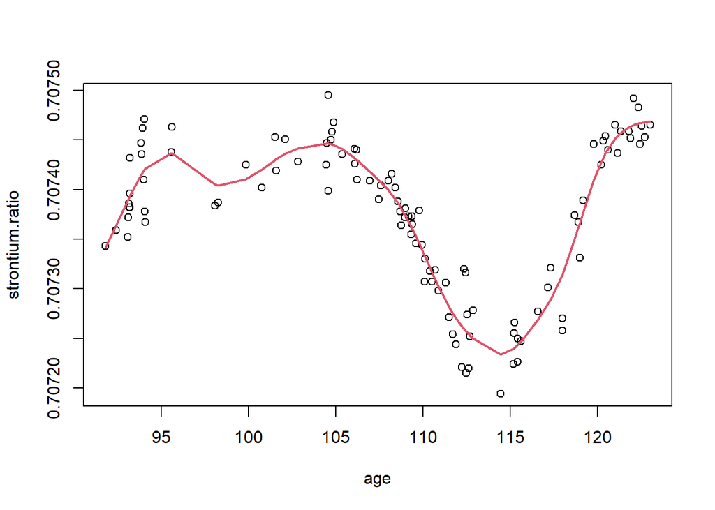

```r
require(SemiPar)
data(fossil)
fossil.spline <- sm.spline(fossil$age, fossil$strontium.ratio)
plot(fossil)
lines(fossil.spline, col=2, lwd=2)
```

With some investigation by looking at the help file (`?sm.spline`), we find that there is an argument `norder` which defaults to the value 2 and that this corresponds indeed to a cubic smoothing spline. We also find from this help file that this function chooses the value $\lambda$ through a cross-validation criterion.

Let us compare this estimate to a local linear estimator. We choose the bandwidth $h=1$ for this purpose which is close to the optimal bandwidth found through `dpill` earlier.

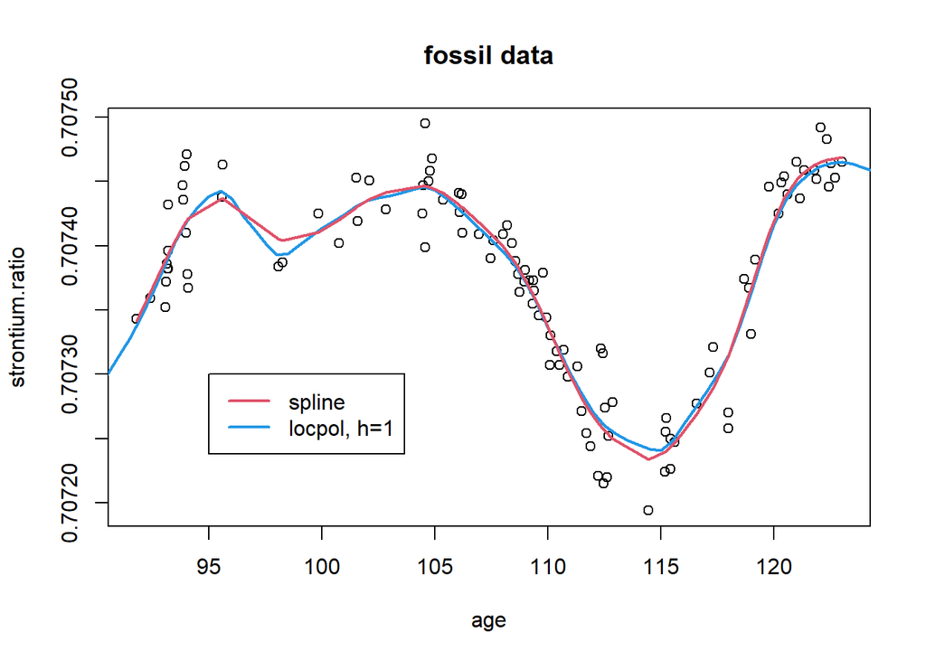

```r
age.grid<- seq(90, 130, by=0.5)
require(locpol)
fit2b<- locpol(strontium.ratio~age, bw=1, deg=1,  kernel=gaussK, xeval=age.grid,  data=fossil)
plot(fossil, main="fossil data")
lines(fit2b$lpFit[1:2], lty=1, lwd=2, col=4)
lines(fossil.spline, col=2, lwd=2)
legend(95,0.70730, c("spline", "locpol, h=1"), lwd=c(2,2), lty=c(1,1), col=c(2,4))
```

We see that the smoothing splines performs smoother at the first dip but manages to get deeper into the second. This could indicate superior behavior of the spline estimate. On the other hand, the estimate appears “edgy” at some points which could be related to the fact that the smoothing spline function is only evaluated at the data points.

A “trick” which is sometimes useful is to apply the `gam` function even for univariate smoothing. This allows access to confidence intervals and other inferential devices. For instance, we get

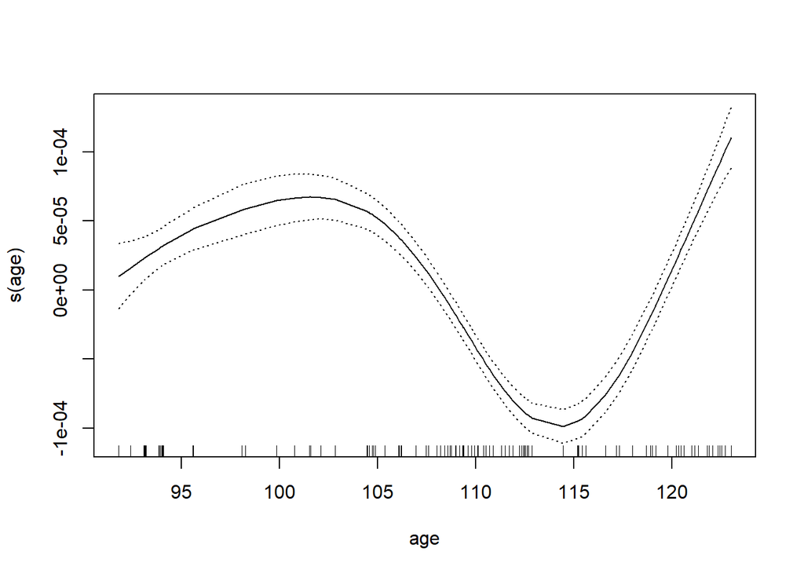

```r
require(gam)
fossil.spline2 <- gam(strontium.ratio~s(age), data=fossil)
plot(fossil.spline2, se=TRUE)
points(fossil)
```

Here again, a look at the help file (`?s`) tells us that this smoother uses 4 degrees of freedom. Since a cubic polynomial has 4 parameters, this indicates correspondence to a cubic smoothing spline. Looking deeper, one finds that the function `s()` in fact makes use of the R function `smooth.spline` in the base R package `stats`, which however implements a B-spline fit, which is different. (Unfortunately, the R function names in this field are very confusing…)

The smoothness of this spline fit is steered by an option `spar` which defaults to the value 1. From the image above and from what we have seen previously for this data set, this looks too large. Let’s try something less smooth…

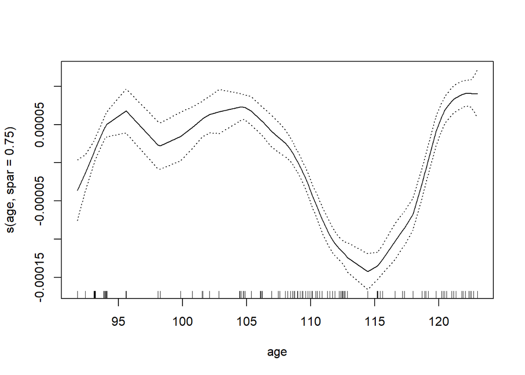

```r
# ?s
fossil.spline3 <- gam(strontium.ratio~s(age, spar=0.75), data=fossil)
plot(fossil.spline3, se=TRUE)
```

This looks now to be of the familiar magnitude. Understandig how smoothing parameters from different smoothers relate to each other is an advanced topic… we stop however here.